# Analysing Sentences Backbone Communities

#### Top terms 1_92: policy_implications, economic_policy, policy_makers, optimal_policy, optimal (1970-1979)

| Sentence | Title | Year | Journal | Authors | Distance to Centroid |
| --- | --- | --- | --- | --- | --- |
| In our view this is a more plausible interpretation of Iyoha’s empirical results.16 The Policy Implications Our third criticism centers on Iyoha’s policy conclusions. | [Inflation and “Openness” in Less Developed Economies: A Cross-Country Analysis: Comment](http://www.jstor.org/stable/1152844) | 1977 | Economic Development and Cultural Change | C. H. Kirkpatrick, F. I. Nixson | 6.795577 |
| III We conclude that even if economists desire to be good Wicksellians, the policy inferences of the Buchanan-Tullock analysis are neither clear nor compelling nor conclusive nor completely possible. | [Polluters’ Profit and Political Response: The Dynamics of Rights Creation](http://www.jstor.org/stable/30022920) | 1976 | Public Choice | Warren J. Samuels, A. Allan Schmid | 6.968429 |
| Okun’s paper, and previous discussions of the same issues, concentrates on the question of how economic policy ought to be made. | [Reflections on U.S. Macroeconomic Policy](http://www.jstor.org/stable/2534077) | 1974 | Brookings Papers on Economic Activity | William Poole | 7.412598 |
| First, it is my intent to identify and systematize or characterize the field of Theory of Economic Policy in general without precluding further and different specification. | [The Scope of Economics Historically Considered](http://www.jstor.org/stable/3145107) | 1972 | Land Economics | Warren J. Samuels | 7.459412 |
| IN THIS brief essay I have picked out certain particular strands of thought, on the basis partly of theoretical significance and partly of relationship to economic policy. | [Some Aspects of the Development of Keynes’s Thought](http://www.jstor.org/stable/2722880) | 1978 | Journal of Economic Literature | Richard Kahn | 7.495565 |

#### Top terms 1_96: rational_expectations, forecasts, forecast, expectations, forecasting (1980-1989)

| Sentence | Title | Year | Journal | Authors | Distance to Centroid |
| --- | --- | --- | --- | --- | --- |
| In many rational expectations applications economists have assumed that rational agents base their forecasts on past price data. | [Reason and Rationality during Energy Crises](http://www.jstor.org/stable/1840436) | 1983 | Journal of Political Economy | George G. Daly , Thomas H. Mayor | 6.434125 |
| We assume that agents’ expectations are rational, which in the context of our information set and in the absence of any further restrictions, identifies price expectations with the projection of futur… | [Money, Real Interest Rates, and Output: A Reinterpretation of Postwar U.S. Data](http://www.jstor.org/stable/1911728) | 1985 | Econometrica | Robert B. Litterman, Laurence Weiss | 6.803375 |
| “Rational Expectations and Macroeconomic Forecasts,” J Bus. | [Recent Work on Business Cycles in Historical Perspective: A Review of Theories and Evidence](http://www.jstor.org/stable/2725624) | 1985 | Journal of Economic Literature | Victor Zarnowitz | 6.925172 |
| Alternatively, price expectations may be formed by the hypothesis of perfect foresight rational expectations1. | [Expected Inflation, Wealth Effects and Personal Expenditure](http://www.jstor.org/stable/40439023) | 1982 | Weltwirtschaftliches Archiv | J. Neill Fortune | 6.938651 |
| This paper will, however, try to outline the evolution of the rational expectations concept from a notion of optimal forecasting to a virtually complete departure from the Walrasian model of equilibri… | [An Introduction to the Theory of Rational Expectations Under Asymmetric Information](http://www.jstor.org/stable/2297195) | 1981 | The Review of Economic Studies | Sanford J. Grossman | 6.992059 |

#### Top terms 1_115: forecasts, forecasters, forecast, rational_expectations, forecast_errors (1990-1999)

| Sentence | Title | Year | Journal | Authors | Distance to Centroid |
| --- | --- | --- | --- | --- | --- |
| Empirical tests of the rational expectations hypothesis using individual forecasts may be biased toward rejecting rationality because they fail to take into account the interplay among forecasters. | [Rational Bias in Macroeconomic Forecasts](http://www.jstor.org/stable/2586954) | 1999 | The Quarterly Journal of Economics | David Laster, Paul Bennett, In Sun Geoum | 6.247431 |
| RATIONALITY, ECONOMIC THEORY, AND FORECASTING METHOD An interesting but hitherto unexplored issue is whether differences in forecast rationality can be attributed to differences in the way forecasts a… | [Blue Chip Rationality Tests](http://www.jstor.org/stable/1992704) | 1991 | Journal of Money, Credit and Banking | Roy Batchelor, Pami Dua | 6.507390 |
| This research casts further doubt on how closely forecaster behavior conforms to rational expectations. | [Rational Bias in Macroeconomic Forecasts](http://www.jstor.org/stable/2586954) | 1999 | The Quarterly Journal of Economics | David Laster, Paul Bennett, In Sun Geoum | 6.558764 |
| Rational expectations and macroeconomic forecasts. | [Bias in OMB’s Economic Forecasts and Budget Proposals](http://www.jstor.org/stable/30025708) | 1993 | Public Choice | Paul R. Blackley, Larry DeBoer | 6.598710 |
| Finally, we examine whether deviations from rationality are associated with the adherence of forecasters to particular economic theories or forecasting methods. | [Blue Chip Rationality Tests](http://www.jstor.org/stable/1992704) | 1991 | Journal of Money, Credit and Banking | Roy Batchelor, Pami Dua | 6.749226 |

### Top articles (most sentences) of the backbone cluster

| Title | Year | Journal | Authors | Number sentences | Words Similarity |
| --- | --- | --- | --- | --- | --- |
| [Testing the Rationality of Price Forecasts: New Evidence from Panel Data](http://www.jstor.org/stable/2006704) | 1990 | The American Economic Review | Michael P. Keane, David E. Runkle | 29 | 0.653 |
| [Blue Chip Rationality Tests](http://www.jstor.org/stable/1992704) | 1991 | Journal of Money, Credit and Banking | Roy Batchelor, Pami Dua | 26 | 0.675 |
| [The Meaning of Rationalization: An Analysis of the Literature](http://www.jstor.org/stable/1883398) | 1932 | The Quarterly Journal of Economics | Robert A. Brady | 18 | 0.635 |
| [Economic Planning Reconsidered](http://www.jstor.org/stable/1884189) | 1958 | The Quarterly Journal of Economics | John E. Elliott | 18 | 0.605 |
| [Problems of Rationalisation](http://www.jstor.org/stable/2224429) | 1930 | The Economic Journal | Stokes , Macgregor | 15 | 0.637 |
| [Towards an Understanding of Market Processes: Individual Expectations, Learning, and Convergence to Rational Expectations Equilibrium](http://www.jstor.org/stable/1810008) | 1982 | The American Economic Review | Roman Frydman | 15 | 0.673 |
| [Why are Professional Forecasters Biased? Agency Versus Behavioral Explanations](http://www.jstor.org/stable/2946656) | 1996 | The Quarterly Journal of Economics | Tilman Ehrbeck , Robert Waldmann | 15 | 0.631 |
| [Rationalisation and Technological Unemployment](http://www.jstor.org/stable/2224241) | 1930 | The Economic Journal | T. E. Gregory | 14 | 0.638 |
| [Mises, Lange, Liberman: Allocation and Motivation in the Socialist Economy](http://www.jstor.org/stable/40436622) | 1968 | Weltwirtschaftliches Archiv | George N. Halm | 14 | 0.603 |
| [The Entrepreneur Myth](http://www.jstor.org/stable/2547873) | 1924 | Economica | M. H. Dobb | 13 | 0.613 |
| [“Capitalism” In Recent German Literature: Sombart and Weber](http://www.jstor.org/stable/1820700) | 1928 | Journal of Political Economy | Talcott Parsons | 13 | 0.613 |
| [“Capitalism” in Recent German Literature: Sombart and Weber (Concluded)](http://www.jstor.org/stable/1822319) | 1929 | Journal of Political Economy | Talcott Parsons | 13 | 0.623 |
| [The Planning Approach in Public Economy: Further Comment](http://www.jstor.org/stable/1882067) | 1941 | The Quarterly Journal of Economics | Herbert A. Simon | 13 | 0.666 |
| [Economic Regulation and Economic Planning](http://www.jstor.org/stable/1804163) | 1939 | The American Economic Review | Karl W. Kapp | 12 | 0.605 |
| [EXTERNAL ECONOMIES FROM A PLANNING STANDPOINT](http://www.jstor.org/stable/40748669) | 1963 | Zeitschrift für die gesamte Staatswissenschaft / Journal of Institutional and Theoretical Economics | WOLFGANG F. STOLPER | 12 | 0.611 |

### Top articles (most sentences) of the cluster for each time window

#### Top articles for 1_9: enjoyment, social_economics, civilization, prosperity, subsistence (1900-1919)

| Title | Year | Journal | Authors | Number sentences | Words Similarity |
| --- | --- | --- | --- | --- | --- |
| [The Social Point of View in Economics](http://www.jstor.org/stable/1884931) | 1913 | The Quarterly Journal of Economics | Lewis H. Haney | 10 | 0.614 |
| [The Relations of Recent Psychological Developments to Economic Theory](http://www.jstor.org/stable/1885945) | 1919 | The Quarterly Journal of Economics | Z. Clark Dickinson | 10 | 0.634 |
| [The Social Possibilities of Economic Chivalry](http://www.jstor.org/stable/2220775) | 1907 | The Economic Journal | Alfred Marshall | 7 | 0.630 |
| [Economic Theory and “Social Reform”](http://www.jstor.org/stable/1820938) | 1915 | Journal of Political Economy | Walton H. Hamilton | 7 | 0.638 |
| [Nassau W. Senior, British Economist, in the Light of Recent Researches: II](http://www.jstor.org/stable/1822413) | 1918 | Journal of Political Economy | S. Leon Levy | 6 | 0.630 |
| [The Price-System and Social Policy](http://www.jstor.org/stable/1820786) | 1918 | Journal of Political Economy | Walton H. Hamilton | 6 | 0.628 |
| [Economic Theory in an Era of Social Readjustment](http://www.jstor.org/stable/1814006) | 1919 | The American Economic Review | J. M. Clark | 6 | 0.618 |
| [A Positive Theory of Economics](http://www.jstor.org/stable/1882745) | 1902 | The Quarterly Journal of Economics | Frederick B. Hawley | 5 | 0.646 |
| [The Social Point of View in Economics](http://www.jstor.org/stable/1883624) | 1914 | The Quarterly Journal of Economics | Lewis H. Haney | 5 | 0.607 |
| [The Concept of Value: A Rejoinder](http://www.jstor.org/stable/1883305) | 1915 | The Quarterly Journal of Economics | J. M. Clark | 5 | 0.627 |

#### Top articles for 1_17: laborer, laborers, workmen, employer, wages (1900-1919)

| Title | Year | Journal | Authors | Number sentences | Words Similarity |
| --- | --- | --- | --- | --- | --- |
| [Böhm-Bawerk on Rae](http://www.jstor.org/stable/1881983) | 1902 | The Quarterly Journal of Economics | Charles W. Mixter | 5 | 0.634 |
| [On Some Neglected British Economists-II](http://www.jstor.org/stable/2221318) | 1903 | The Economic Journal | Edwin R. A. Seligman | 5 | 0.626 |
| [The Development of Ricardo’s Theory of Value](http://www.jstor.org/stable/1882412) | 1904 | The Quarterly Journal of Economics | Jacob H. Hollander | 5 | 0.631 |
| [Some Theoretical Objections to Sliding-Scales](http://www.jstor.org/stable/2220884) | 1903 | The Economic Journal | S. J. Chapman | 4 | 0.632 |
| [Hobson’s Theory of Distribution](http://www.jstor.org/stable/1833343) | 1904 | Journal of Political Economy | J. Laurence Laughlin | 4 | 0.631 |
| [The Theory of Distribution](http://www.jstor.org/stable/1882785) | 1904 | The Quarterly Journal of Economics | F. Y. Edgeworth | 4 | 0.634 |
| [The Division of Income](http://www.jstor.org/stable/1882657) | 1905 | The Quarterly Journal of Economics | Edwin Cannan | 4 | 0.601 |
| [Specific Productivity](http://www.jstor.org/stable/1885300) | 1914 | The Quarterly Journal of Economics | Walter M. Adriance | 4 | 0.611 |
| [Scientific Management and Labor Welfare](http://www.jstor.org/stable/1817657) | 1916 | Journal of Political Economy | Robert F. Hoxie | 4 | 0.614 |
| [Wage Theory and Theories](http://www.jstor.org/stable/1884735) | 1919 | The Quarterly Journal of Economics | H. J. Davenport | 4 | 0.605 |

#### Top articles for 1_28: rationalisation, productive_capacity, cotton, industries, productive_resources (1920-1939)

| Title | Year | Journal | Authors | Number sentences | Words Similarity |
| --- | --- | --- | --- | --- | --- |
| [Rationalisation and Technological Unemployment](http://www.jstor.org/stable/2224241) | 1930 | The Economic Journal | T. E. Gregory | 14 | 0.638 |
| [Problems of Rationalisation](http://www.jstor.org/stable/2224429) | 1930 | The Economic Journal | Stokes , Macgregor | 14 | 0.633 |
| [The Meaning of Rationalization: An Analysis of the Literature](http://www.jstor.org/stable/1883398) | 1932 | The Quarterly Journal of Economics | Robert A. Brady | 10 | 0.636 |
| [Rationalisation of Industry](http://www.jstor.org/stable/2223585) | 1927 | The Economic Journal | D. H. MacGregor | 7 | 0.653 |
| [Saint-Simonism and the Rationalisation of Industry](http://www.jstor.org/stable/1883248) | 1931 | The Quarterly Journal of Economics | E. S. Mason | 7 | 0.623 |
| [Professor Fisher’s Interest Theory: A Case in Point](http://www.jstor.org/stable/1822329) | 1931 | Journal of Political Economy | Frank H. Knight | 7 | 0.597 |
| [“The Common Sense of Political Economy” (Wicksteed Reprinted)](http://www.jstor.org/stable/1824459) | 1934 | Journal of Political Economy | Frank H. Knight | 7 | 0.619 |
| [Economic Evolution: Dialectical and Darwinian](http://www.jstor.org/stable/1830603) | 1934 | Journal of Political Economy | Abram L. Harris | 7 | 0.598 |
| [Some Notes on Ideal Output](http://www.jstor.org/stable/2224577) | 1935 | The Economic Journal | R. F. Kahn | 7 | 0.611 |
| [Increasing Returns and Economic Progress](http://www.jstor.org/stable/2224097) | 1928 | The Economic Journal | Allyn A. Young | 6 | 0.618 |

#### Top articles for 1_30: capitalistic, capitalism, collectivist, capitalist, socialist (1920-1939)

| Title | Year | Journal | Authors | Number sentences | Words Similarity |
| --- | --- | --- | --- | --- | --- |
| [“Capitalism” in Recent German Literature: Sombart and Weber (Concluded)](http://www.jstor.org/stable/1822319) | 1929 | Journal of Political Economy | Talcott Parsons | 13 | 0.623 |
| [The Entrepreneur Myth](http://www.jstor.org/stable/2547873) | 1924 | Economica | M. H. Dobb | 11 | 0.615 |
| [The Soviet Conception of Economic Equilibrium](http://www.jstor.org/stable/2967396) | 1939 | The Review of Economic Studies | E. M. Chossudowsky | 11 | 0.612 |
| [Economic Regulation and Economic Planning](http://www.jstor.org/stable/1804163) | 1939 | The American Economic Review | Karl W. Kapp | 11 | 0.605 |
| [“Capitalism” In Recent German Literature: Sombart and Weber](http://www.jstor.org/stable/1820700) | 1928 | Journal of Political Economy | Talcott Parsons | 10 | 0.609 |
| [Marxian Economics and Modern Economic Theory](http://www.jstor.org/stable/2967586) | 1935 | The Review of Economic Studies | O. Lange | 10 | 0.600 |
| [Economics and the Idea of Natural Laws](http://www.jstor.org/stable/1885439) | 1929 | The Quarterly Journal of Economics | O. H. Taylor | 9 | 0.624 |
| [The Meaning of Rationalization: An Analysis of the Literature](http://www.jstor.org/stable/1883398) | 1932 | The Quarterly Journal of Economics | Robert A. Brady | 8 | 0.634 |
| [The Newer Economics and the Control of Economic Activity](http://www.jstor.org/stable/1822849) | 1932 | Journal of Political Economy | Frank H. Knight | 8 | 0.629 |
| [“The Nature and Significance of Economic Science” in Recent Discussion](http://www.jstor.org/stable/1883978) | 1933 | The Quarterly Journal of Economics | R. W. Souter | 8 | 0.626 |

#### Top articles for 1_34: planning, economic_planning, governmental, planned, social_policy (1940-1949)

| Title | Year | Journal | Authors | Number sentences | Words Similarity |
| --- | --- | --- | --- | --- | --- |
| [The Planning Approach in Public Economy: Further Comment](http://www.jstor.org/stable/1882067) | 1941 | The Quarterly Journal of Economics | Herbert A. Simon | 7 | 0.660 |
| [The Party System and the New Economic Policies](http://www.jstor.org/stable/137415) | 1943 | The Canadian Journal of Economics and Political Science / Revue canadienne d’Economique et de Science politique | F. E. Dessauer | 7 | 0.638 |
| [Economic Planning and the Science of Economics: Comment](http://www.jstor.org/stable/1803245) | 1941 | The American Economic Review | Carl Landauer | 6 | 0.595 |
| [Economic Planning in a Democratic Society](http://www.jstor.org/stable/3158972) | 1943 | The Journal of Land & Public Utility Economics | Dudley F. Pegrum | 6 | 0.605 |
| [The Scope and Method of Economics](http://www.jstor.org/stable/2296113) | 1945 | The Review of Economic Studies | O. Lange | 6 | 0.639 |
| [Law and Economics](http://www.jstor.org/stable/1802253) | 1946 | The American Economic Review | I. L. Sharfman | 6 | 0.600 |
| [The Short View and the Long in Economic Policy](http://www.jstor.org/stable/1807636) | 1940 | The American Economic Review | Jacob Viner | 5 | 0.593 |
| [“Post-war Plan and Program”](http://www.jstor.org/stable/1828574) | 1943 | Journal of Political Economy | Myron W. Watkins | 5 | 0.613 |
| [The Planning Approach in Public Economy: A Reply](http://www.jstor.org/stable/1882066) | 1941 | The Quarterly Journal of Economics | Richard Abel Musgrave | 4 | 0.647 |
| [Social Biases and Recent Theories of Competition](http://www.jstor.org/stable/1885753) | 1943 | The Quarterly Journal of Economics | William H. Nicholls | 4 | 0.596 |

#### Top articles for 1_45: private_enterprise, enterprise_system, free_enterprise, capitalistic, liberty (1940-1949)

| Title | Year | Journal | Authors | Number sentences | Words Similarity |
| --- | --- | --- | --- | --- | --- |
| [Political Economy and Enterprise](http://www.jstor.org/stable/138093) | 1949 | The Canadian Journal of Economics and Political Science / Revue canadienne d’Economique et de Science politique | W. T. Easterbrook | 11 | 0.614 |
| [The Role of the Individual in the Economic World of the Future](http://www.jstor.org/stable/1825328) | 1941 | Journal of Political Economy | Frank H. Knight | 7 | 0.587 |
| [The Appeal of Communist Ideology](http://www.jstor.org/stable/3483469) | 1943 | The American Journal of Economics and Sociology | Harry Gunnison Brown | 7 | 0.610 |
| [Some Remarks on “The Theory of Social and Economic Organization”](http://www.jstor.org/stable/2549708) | 1948 | Economica | Edward A. Shils | 7 | 0.616 |
| [The Economics of a “Free” Society: Four Essays](http://www.jstor.org/stable/1883465) | 1948 | The Quarterly Journal of Economics | O. H. Taylor | 7 | 0.593 |
| [The Planning Approach in Public Economy: Further Comment](http://www.jstor.org/stable/1882067) | 1941 | The Quarterly Journal of Economics | Herbert A. Simon | 6 | 0.674 |
| [The Role of the State: The Role of the State in Shaping Things Economic](http://www.jstor.org/stable/2113272) | 1947 | The Journal of Economic History | Joseph J. Spengler | 6 | 0.603 |
| [Optimum Income Distribution as a Goal of Public Policy](http://www.jstor.org/stable/3483786) | 1944 | The American Journal of Economics and Sociology | Rainer Schickele | 5 | 0.613 |
| [Law and Economics](http://www.jstor.org/stable/1802253) | 1946 | The American Economic Review | I. L. Sharfman | 5 | 0.632 |
| [On the Politics of the Classical Economists](http://www.jstor.org/stable/1883468) | 1948 | The Quarterly Journal of Economics | William D. Grampp | 5 | 0.595 |

#### Top articles for 1_48: planning, optimum_allocation, economic_planning, allocation, resource_allocation (1950-1959)

| Title | Year | Journal | Authors | Number sentences | Words Similarity |
| --- | --- | --- | --- | --- | --- |
| [Economic Planning Reconsidered](http://www.jstor.org/stable/1884189) | 1958 | The Quarterly Journal of Economics | John E. Elliott | 18 | 0.605 |
| [A Re-Appraisal of the Principles of Resource Allocation](http://www.jstor.org/stable/2550422) | 1957 | Economica | E. J. Mishan | 9 | 0.610 |
| [Scarcity, Marxism, and Gosplan](http://www.jstor.org/stable/2662131) | 1953 | Oxford Economic Papers | P. J. D. Wiles | 7 | 0.604 |
| [The Economic Way of Thinking](http://www.jstor.org/stable/1802807) | 1950 | The American Economic Review | Howard S. Ellis | 6 | 0.619 |
| [Imperfect Knowledge and Economic Efficiency](http://www.jstor.org/stable/2661972) | 1953 | Oxford Economic Papers | G. B. Richardson | 6 | 0.626 |
| [Conservation Policy and Capital Theory](http://www.jstor.org/stable/138559) | 1954 | The Canadian Journal of Economics and Political Science / Revue canadienne d’Economique et de Science politique | Anthony Scott | 6 | 0.622 |
| [Some Thoughts on Marxism, Scarcity, and Gosplan](http://www.jstor.org/stable/2662053) | 1955 | Oxford Economic Papers | Ronald L. Meek | 6 | 0.613 |
| [THE ROLE OF PLANNING IN SOCIALIST ECONOMY](http://www.jstor.org/stable/29793153) | 1958 | Indian Economic Review | Oskar Lange | 6 | 0.606 |
| [Resourcefulness and Responsibility](http://www.jstor.org/stable/138768) | 1958 | The Canadian Journal of Economics and Political Science / Revue canadienne d’Economique et de Science politique | Anthony Scott | 6 | 0.609 |
| [THE PROBLEM OF MARGINAL-COST PRICING RECONSIDERED](http://www.jstor.org/stable/45149593) | 1952 | Indian Economic Review | Maurice Dobb | 5 | 0.613 |

#### Top articles for 1_66: planning, economic_planning, planners, optimum_allocation, resource_allocation (1960-1969)

| Title | Year | Journal | Authors | Number sentences | Words Similarity |
| --- | --- | --- | --- | --- | --- |
| [Mises, Lange, Liberman: Allocation and Motivation in the Socialist Economy](http://www.jstor.org/stable/40436622) | 1968 | Weltwirtschaftliches Archiv | George N. Halm | 12 | 0.602 |
| [The Information Effect of Economic Planning](http://www.jstor.org/stable/139702) | 1964 | The Canadian Journal of Economics and Political Science / Revue canadienne d’Economique et de Science politique | Fernand Martin | 11 | 0.607 |
| [EXTERNAL ECONOMIES FROM A PLANNING STANDPOINT](http://www.jstor.org/stable/40748669) | 1963 | Zeitschrift für die gesamte Staatswissenschaft / Journal of Institutional and Theoretical Economics | WOLFGANG F. STOLPER | 9 | 0.602 |
| [Fundamental Characteristics of the Yugoslav Economic System](http://www.jstor.org/stable/4379264) | 1963 | Eastern European Economics | Vojislav Rakić | 6 | 0.592 |
| [The Enterprise Under Central Planning](http://www.jstor.org/stable/2296837) | 1969 | The Review of Economic Studies | R. D. Portes | 6 | 0.601 |
| [Input-Output Analysis and Soviet Planning](http://www.jstor.org/stable/1910876) | 1962 | The American Economic Review | Herbert S. Levine | 5 | 0.632 |
| [The Theory of Balanced Growth](http://www.jstor.org/stable/2661956) | 1962 | Oxford Economic Papers | S. K. Nath | 5 | 0.601 |
| [Are Formal Welfare Criteria Required?](http://www.jstor.org/stable/2228296) | 1964 | The Economic Journal | S. K. Nath | 5 | 0.627 |
| [The Soviet Price Reform Discussion](http://www.jstor.org/stable/1880544) | 1964 | The Quarterly Journal of Economics | Morris Bornstein | 5 | 0.619 |
| [Comprehensive Model-Building in the Planning Process: The Case of the Less-Developed Economies](http://www.jstor.org/stable/2229037) | 1966 | The Economic Journal | Raymond Vernon | 5 | 0.601 |

#### Top articles for 1_71: economic_development, industrial_production, underdeveloped, economic_growth, technical_progress (1960-1969)

| Title | Year | Journal | Authors | Number sentences | Words Similarity |
| --- | --- | --- | --- | --- | --- |
| [Institutions and Technology in Economic Progress: Schumpeter’s Theory of Economic Development as a Special Case of the Institutionalist Theory](http://www.jstor.org/stable/3484774) | 1960 | The American Journal of Economics and Sociology | H. H. Liebhafsky | 7 | 0.594 |
| [A Theory of Economic Development](http://www.jstor.org/stable/40434654) | 1960 | Weltwirtschaftliches Archiv | Giuseppe Ugo Papi | 7 | 0.595 |
| [The Regional Aspect of Economic Development](http://www.jstor.org/stable/4379258) | 1963 | Eastern European Economics | Kosta Mihailović | 7 | 0.632 |
| [A Survey of Welfare Economics, 1939-59](http://www.jstor.org/stable/2228726) | 1960 | The Economic Journal | E. J. Mishan | 5 | 0.620 |
| [SOME REFLECTIONS ON THE ECONOMIC UTOPIA](http://www.jstor.org/stable/29793243) | 1961 | Indian Economic Review | V. K. R. V. Rao | 5 | 0.591 |
| [Second Thoughts on Second Best](http://www.jstor.org/stable/2661736) | 1962 | Oxford Economic Papers | E. J. Mishan | 5 | 0.626 |
| [The Price of Growth](http://www.jstor.org/stable/2228170) | 1963 | The Economic Journal | T. Wilson | 5 | 0.628 |
| [On the Optimum Rate of Savings](http://www.jstor.org/stable/40436772) | 1963 | Weltwirtschaftliches Archiv | Arnold Heertje | 5 | 0.616 |
| [An Economic Theory of Protectionism, Tariff Bargaining, and the Formation of Customs Unions](http://www.jstor.org/stable/1829039) | 1965 | Journal of Political Economy | Harry G. Johnson | 5 | 0.607 |
| [The Scope and Content of Resource Policy in Relation to Economic Development](http://www.jstor.org/stable/3159835) | 1961 | Land Economics | Morris Miller | 4 | 0.590 |

#### Top articles for 1_92: policy_implications, economic_policy, policy_makers, optimal_policy, optimal (1970-1979)

| Title | Year | Journal | Authors | Number sentences | Words Similarity |
| --- | --- | --- | --- | --- | --- |
| [Synoptic versus Incremental Scholarly Advice in Economic Policy: Some Implications of So-Called “Rational” Tax Systems](http://www.jstor.org/stable/40910769) | 1970 | FinanzArchiv / Public Finance Analysis | Gunther Engelhardt | 10 | 0.608 |
| [Introduction to the Study of Economic Policy](http://www.jstor.org/stable/4379531) | 1976 | Eastern European Economics | István Friss, George Hajdu | 8 | 0.617 |
| [On the Effects of Policy Costs](http://www.jstor.org/stable/3439361) | 1974 | The Swedish Journal of Economics | Peter Bohm | 6 | 0.594 |
| [Rules Rather than Discretion: The Inconsistency of Optimal Plans](http://www.jstor.org/stable/1830193) | 1977 | Journal of Political Economy | Finn E. Kydland , Edward C. Prescott | 6 | 0.606 |
| [The Ambiguous Rationality of Economic Policy](http://www.jstor.org/stable/1991399) | 1972 | Journal of Money, Credit and Banking | Karl Brunner | 5 | 0.663 |
| [The Scope of Economics Historically Considered](http://www.jstor.org/stable/3145107) | 1972 | Land Economics | Warren J. Samuels | 5 | 0.601 |
| [A Model of Cyclical Fluctuations under Socialism](http://www.jstor.org/stable/4224287) | 1974 | Journal of Economic Issues | Lawrence J. Brainard | 5 | 0.602 |
| [Economic Policy Design: Principles and Urban Applications](http://www.jstor.org/stable/40324603) | 1974 | Eastern Economic Journal | Thomas Vietorisz | 5 | 0.589 |
| [Harry Johnson’s Contributions to the Pure Theory of International Trade](http://www.jstor.org/stable/134513) | 1978 | The Canadian Journal of Economics / Revue canadienne d’Economique | Richard G. Lipsey | 5 | 0.659 |
| [Money, Efficiency, and Knowledge](http://www.jstor.org/stable/134866) | 1979 | The Canadian Journal of Economics / Revue canadienne d’Economique | T. K. Rymes | 5 | 0.614 |

#### Top articles for 1_96: rational_expectations, forecasts, forecast, expectations, forecasting (1980-1989)

| Title | Year | Journal | Authors | Number sentences | Words Similarity |
| --- | --- | --- | --- | --- | --- |
| [Towards an Understanding of Market Processes: Individual Expectations, Learning, and Convergence to Rational Expectations Equilibrium](http://www.jstor.org/stable/1810008) | 1982 | The American Economic Review | Roman Frydman | 15 | 0.673 |
| [The Expectation Formation Behavior of the Inventory-Holding Firm](http://www.jstor.org/stable/25603538) | 1982 | The American Economist | Sherry S. Atkinson | 9 | 0.634 |
| [Are Livestock Futures Prices Rational Forecasts?](http://www.jstor.org/stable/40987807) | 1986 | Western Journal of Agricultural Economics | J. S. Shonkwiler | 9 | 0.681 |
| [Econometric Implications of the Rational Expectations Hypothesis](http://www.jstor.org/stable/1912018) | 1980 | Econometrica | Kenneth F. Wallis | 8 | 0.645 |
| [Are Market Forecasts Rational?](http://www.jstor.org/stable/1802780) | 1981 | The American Economic Review | Frederic S. Mishkin | 8 | 0.631 |
| [Is Optimism Good in a Keynesian Economy?](http://www.jstor.org/stable/2553971) | 1983 | Economica | Torsten Persson , Lars E. O. Svensson | 8 | 0.600 |
| [A Theoretical and Empirical Approach to the Value of Information in Risky Markets](http://www.jstor.org/stable/1924933) | 1986 | The Review of Economics and Statistics | Frances Antonovitz, Terry Roe | 8 | 0.650 |
| [An Indirect Test for the Specification of Expectation Regimes](http://www.jstor.org/stable/1924519) | 1986 | The Review of Economics and Statistics | Peter Orazem , John Miranowski | 8 | 0.626 |
| [Recent Work on Business Cycles in Historical Perspective: A Review of Theories and Evidence](http://www.jstor.org/stable/2725624) | 1985 | Journal of Economic Literature | Victor Zarnowitz | 7 | 0.676 |
| [Rational Expectations: A Fallacious Foundation for Studying Crucial Decision-Making Processes](http://www.jstor.org/stable/4537730) | 1982 | Journal of Post Keynesian Economics | Paul Davidson | 6 | 0.629 |

#### Top articles for 1_115: forecasts, forecasters, forecast, rational_expectations, forecast_errors (1990-1999)

| Title | Year | Journal | Authors | Number sentences | Words Similarity |
| --- | --- | --- | --- | --- | --- |
| [Testing the Rationality of Price Forecasts: New Evidence from Panel Data](http://www.jstor.org/stable/2006704) | 1990 | The American Economic Review | Michael P. Keane, David E. Runkle | 29 | 0.653 |
| [Blue Chip Rationality Tests](http://www.jstor.org/stable/1992704) | 1991 | Journal of Money, Credit and Banking | Roy Batchelor, Pami Dua | 26 | 0.675 |
| [Why are Professional Forecasters Biased? Agency Versus Behavioral Explanations](http://www.jstor.org/stable/2946656) | 1996 | The Quarterly Journal of Economics | Tilman Ehrbeck , Robert Waldmann | 15 | 0.631 |
| [In Search of a “Strictly Rational” Forecast](http://www.jstor.org/stable/2109514) | 1991 | The Review of Economics and Statistics | Carl S. Bonham , Douglas C. Dacy | 11 | 0.659 |
| [Are Farrowing Intentions Rational Forecasts?](http://www.jstor.org/stable/1242812) | 1991 | American Journal of Agricultural Economics | David E. Runkle | 10 | 0.641 |
| [Rational Bias in Macroeconomic Forecasts](http://www.jstor.org/stable/2586954) | 1999 | The Quarterly Journal of Economics | David Laster, Paul Bennett, In Sun Geoum | 10 | 0.634 |
| [Tests of Rational Expectations in a Stark Setting](http://www.jstor.org/stable/2234533) | 1993 | The Economic Journal | Gerald P. Dwyer, Jr., Arlington W. Williams , Raymond C. Battalio , Timothy I. Mason | 9 | 0.632 |
| [Economic Forecasts, Rationality, and the Processing of New Information over Time](http://www.jstor.org/stable/1992128) | 1990 | Journal of Money, Credit and Banking | Steve Swidler, David Ketcher | 7 | 0.652 |
| [On the Rationality of Forecasts](http://www.jstor.org/stable/2109530) | 1991 | The Review of Economics and Statistics | Bong-Soo Lee | 7 | 0.671 |
| [Imperfect Competition, Expectations and the Multiple Effects of Monetary Growth](http://www.jstor.org/stable/2234574) | 1992 | The Economic Journal | Neil Rankin | 6 | 0.640 |

### Most cited references in the backbone community

| First Author | Year | Journal | Citation by article | Citation by sentence |
| --- | --- | --- | --- | --- |
| MUTH-J | 1961 | ECONOMETRICA | 81 | 3888 |
| FISCHER-S | 1977 | J POLITICAL EC | 44 | 264 |
| LUCAS-R | 1972 | J EC THEORY | 40 | 200 |
| SARGENT-T | 1975 | J POLITICAL EC | 46 | 184 |
| LUCAS-R | 1975 | JPE | 34 | 170 |
| FRIEDMAN-M | 1968 | AER | 26 | 104 |
| DORNBUSCH-R | 1976 | J POLIT EC | 33 | 99 |
| COASE-R | 1960 | J LAW EC | 14 | 42 |
| BARRO-R | 1976 | J MONETARY EC | 12 | 36 |
| SOLOW-R | 1957 | REV EC STATISTICS | 11 | 33 |
| LUCAS-R | 1973 | AER | 28 | 28 |
| CAZES-B | 1963 | ASTEF FEV | 2 | 22 |
| MARXK | 1932 | GESAMTAUSGABE 1 | 4 | 20 |
| BARRO-R | 1977 | AER | 17 | 17 |
| SARGENT-T | 1976 | J POLITICAL EC | 17 | 17 |

| First Author | Year | Journal | Citation by article | Citation by sentence |
| --- | --- | --- | --- | --- |
| KEYNES-J | 1936 | GENERAL THEORY EMPLO | 68 | 2992 |
| SARGENT-T | 1979 | MACROECONOMIC THEORY | 32 | 480 |
| LUCAS-R | 1976 | PHILLIPS CURVE LABOR | 29 | 377 |
| KEYNES-J | 1973 | COLLECTED WRITINGS J | 47 | 282 |
| MEADE-J | 1955 | THEORY CUSTOMS UNION | 22 | 154 |
| KNIGHT-F | 1921 | RISK UNCERTAINTY PRO | 10 | 150 |
| MALINVAUD-E | 1977 | THEORY UNEMPLOYMENT | 19 | 133 |
| LEIJONHUFVUD-A | 1968 | KEYNESIAN EC EC KEYN | 18 | 126 |
| SARGENT-T | 1987 | MACROECONOMIC THEORY | 14 | 126 |
| LEIJONHUFVUD-A | 1981 | INFORMATION COORDINA | 8 | 120 |
| LUCAS-R | 1981 | RATIONAL EXPECTATION | 20 | 120 |
| HIRSCHMAN-A | 1958 | STRATEGY EC DEV | 17 | 119 |
| OKUN-A | 1981 | PRICES QUANTITIES MA | 15 | 105 |
| PATINKIN-D | 1965 | MONEY INTEREST PRICE | 15 | 105 |
| KAHNEMAN-D | 1982 | JUDGMENT UNCERTAINTY | 4 | 60 |

### Most cited references per kmean clusters

#### Top references 1_34: planning, economic_planning, governmental, planned, social_policy (1940-1949)

| First Author | Year | Journal | Citation by article | Citation by sentence |
| --- | --- | --- | --- | --- |
| FISHER-I | 1927 | EC ESSAYS CONTRIBUTE | 1 | 3 |
| TINTNER-G | 1946 | ECONOMETRICA | 1 | 3 |
| LANGE-O | 1942 | ECONOMETRICA | 1 | 3 |
| CLARKJM | 1946 | J POLITICAL EC | 1 | 3 |
| DURBIN | 1935 | NEW TRENDS SOCIALISM | 1 | 3 |
| *BURFORDOMCOMM | 1947 | SURV CURR BUS S | 1 | 3 |
| *BURLABSTAT | 1941 | B BUR LAB STAT | 1 | 3 |
| *USBUSCENS | 1947 | STAT ABSTR US | 1 | 3 |
| CLARKJM | 1947 | ECONOMETRICA | 1 | 3 |
| KNIGHTFH | 1944 | J POLITICAL EC | 1 | 3 |

| First Author | Year | Journal | Citation by article | Citation by sentence |
| --- | --- | --- | --- | --- |
| *AMECASS | 1946 | 58 ANN M AM EC ASS | 1 | 6 |
| LANGEO | 1938 | EC THEORY SOCIALISM | 3 | 6 |
| LERNERAP | 1944 | EC CONTROL | 2 | 4 |
| *USSTATDEP | 1947 | US STAT DEP PUBS | 3 | 3 |
| SMITHA | 1812 | THEORY MORAL SENTI 6 | 3 | 3 |
| WOOTTONB | 1945 | FREEDOM PLANNING | 1 | 3 |
| BONINSEGNIP | 1902 | GIORNALE EC | 1 | 3 |
| EDGEWORTHFY | 1881 | MATH PHYS | 1 | 3 |
| FRISCHR | 1932 | NEW METHODS MEASURIN | 1 | 3 |
| REDERONMW | 1947 | STUDIES HIST EC PUBL | 1 | 3 |

#### Top references 1_45: private_enterprise, enterprise_system, free_enterprise, capitalistic, liberty (1940-1949)

| First Author | Year | Journal | Citation by article | Citation by sentence |
| --- | --- | --- | --- | --- |
| KNIGHTFH | 1947 | FREEDOM REFORM | 1 | 11 |
| BREBNERJB | 1948 | TASKS EC HIST S | 1 | 11 |
| HENDERSONH | 1948 | EC J DEC | 1 | 11 |
| OAKESHOTTM | 1949 | CAMBRIDGE J JAN | 1 | 11 |
| ROBBINSL | 1947 | EC PROBLEM PEACE WAR | 1 | 11 |
| SIMONSHC | 1948 | EC POLICY FREE SOC | 1 | 11 |
| TAYLOROH | 1948 | Q J EC NOV | 1 | 11 |
| WRIGHTDM | 1947 | DEMOCRACY PROGR | 1 | 11 |
| MARXK | 1932 | GESAMTAUSGABE 1 | 2 | 8 |
| SMITHA | 1937 | WEALTH NATIONS | 1 | 5 |

| First Author | Year | Journal | Citation by article | Citation by sentence |
| --- | --- | --- | --- | --- |
| CLARKJM | 1948 | ALTERNATIVE SERFDOM | 3 | 21 |
| LERNERAP | 1944 | EC CONTROL | 5 | 15 |
| AITKENH | 1949 | EXPLORATIONS ENTREPR | 1 | 11 |
| EASTERBROOKWT | 1949 | P AM EC ASS MAY | 1 | 11 |
| HARDYCO | 1948 | J POLITICAL EC AUG | 1 | 11 |
| HARTZL | 1948 | EC POLICY DEMOCRATIC | 1 | 11 |
| BLADENVW | 1948 | J EC HIST S | 3 | 9 |
| WALKERER | 1943 | EC THEORY POLICY | 2 | 8 |
| JEWKESJ | 1948 | ORDEAL PLANNING | 1 | 7 |
| SIMONSH | 1948 | EC POLICY FREE SOC | 1 | 7 |

#### Top references 1_48: planning, optimum_allocation, economic_planning, allocation, resource_allocation (1950-1959)

| First Author | Year | Journal | Citation by article | Citation by sentence |
| --- | --- | --- | --- | --- |
| REDER-M | 1947 | STUDIES THEORY WELFA | 1 | 9 |
| GOSSENHH | 1854 | ENTWICKLUNG GESETZE | 1 | 7 |
| BERGSON | 1950 | Q J ECON | 1 | 7 |
| BERLINER | 1952 | Q J ECON | 1 | 7 |
| DOBBM | 1917 | SOVIET EC DEV SINCE | 1 | 7 |
| KAPLAN | 1953 | J POLITICAL EC | 1 | 7 |
| KASER | 1950 | ECON J | 1 | 7 |
| MARSHEV | 1948 | NEFTYANOE KHOZYAISTV | 1 | 7 |
| MIROSHNICHENKO | 1951 | PLANOVOE KHOZYAISTVO | 1 | 7 |
| SMEKHOV | 1951 | PLANOVOE KHOZYAISTVO | 1 | 7 |

| First Author | Year | Journal | Citation by article | Citation by sentence |
| --- | --- | --- | --- | --- |
| ALLEN | 1953 | Q J ECON | 1 | 18 |
| BODE | 1943 | AM EC REV | 1 | 18 |
| ELLIS | 1950 | AM EC REV | 1 | 18 |
| FRIEDMAN | 1948 | AM EC REV | 1 | 18 |
| NOURSE | 1946 | PUBLIC ADM REV | 1 | 18 |
| VINER | 1940 | AM EC REV | 1 | 18 |
| HICKS-J | 1939 | EC J DEC | 2 | 18 |
| SCITOVSKY | 1942 | REV EC STUDIES | 2 | 18 |
| FLEMING-M | 1955 | EC J | 3 | 15 |
| VONCIRIACYWANTR.S | 1952 | RESOURCE CONSERVATIO | 2 | 12 |

#### Top references 1_66: planning, economic_planning, planners, optimum_allocation, resource_allocation (1960-1969)

| First Author | Year | Journal | Citation by article | Citation by sentence |
| --- | --- | --- | --- | --- |
| CAZES-B | 1963 | ASTEF FEV | 2 | 22 |
| ADELMAN-M | 1948 | HARVARD LAW REV | 1 | 11 |
| SCHELLING-T | 1960 | STRATEGY CONFLICT | 1 | 11 |
| SCITOVSKY-T | 1954 | J POLITICAL EC | 1 | 11 |
| KOOPMANS-T | 1957 | 3 ESSAYS STATE EC SC | 1 | 11 |
| HIRSCHMAN-A | 1958 | STRATEGY EC DEV | 1 | 11 |
| ARROW-K | 1960 | EC APPLIQUEE | 1 | 11 |
| BAUCHET-P | 1958 | EXPERIENCE FRANCAISE | 1 | 11 |
| DELAPERRIERE-G | 1963 | TECHNIQUES FRANCAISE | 1 | 11 |
| DEWOLFF-P | 1962 | PLANNING OXFORD | 1 | 11 |

| First Author | Year | Journal | Citation by article | Citation by sentence |
| --- | --- | --- | --- | --- |
| MCKEAN-R | 1958 | EFFICIENCY GOVT SYST | 8 | 40 |
| HIRSCHMAN-A | 1958 | STRATEGY EC DEV | 7 | 28 |
| BERGSON-A | 1948 | SURVEY CONTEMPORARY | 4 | 24 |
| SAMUELSON-P | 1947 | F ECONOMIC ANALYSIS | 4 | 24 |
| MASSE-P | 1962 | OPTIMAL INVESTMENT D | 4 | 20 |
| SEN-A | 1960 | CHOICE TECHNIQUES | 6 | 18 |
| MEADE-J | 1955 | THEORY CUSTOMS UNION | 9 | 18 |
| BERGSON-A | 1964 | ECONOMICS SOVIET PLA | 3 | 18 |
| DEBREU-G | 1959 | THEORY VALUE | 4 | 16 |
| BECKER-G | 1962 | J POLITICAL EC | 4 | 16 |

#### Top references 1_71: economic_development, industrial_production, underdeveloped, economic_growth, technical_progress (1960-1969)

| First Author | Year | Journal | Citation by article | Citation by sentence |
| --- | --- | --- | --- | --- |
| ARROW-K | 1950 | J POLIT ECON | 2 | 10 |
| ARMSTRONG-W | 1951 | OXFORD ECON PAP | 2 | 10 |
| ROTHENBERG-J | 1953 | OXFORD EC PAPERS | 2 | 10 |
| MAJUMDAR-T | 1957 | OEP | 2 | 10 |
| ARROW-K | 1961 | REV ECON STAT | 8 | 8 |
| SOLOW-R | 1957 | REV EC STATISTICS | 8 | 8 |
| YOUNG-K | 1942 | SOCIOLOGY | 1 | 7 |
| SOLO-C | 1951 | Q J EC | 1 | 7 |
| SILBERMAN-L | 1956 | ANN AM ACADEMY POLIT | 1 | 7 |
| SCHUMPETER-J | 1950 | CAPITALISM SOCIALISM | 1 | 7 |

| First Author | Year | Journal | Citation by article | Citation by sentence |
| --- | --- | --- | --- | --- |
| MEADE-J | 1955 | THEORY CUSTOMS UNION | 13 | 65 |
| DENISON-E | 1962 | SOURCES EC GROWTH US | 12 | 48 |
| DORFMAN-R | 1958 | LINEAR PROGRAMMING E | 8 | 40 |
| ROBINSON-J | 1956 | ACCUMULATION CAPITAL | 9 | 36 |
| ARROW-K | 1951 | SOCIAL CHOICE INDIVI | 7 | 35 |
| HARROD-R | 1948 | DYNAMIC EC | 8 | 32 |
| SCHULTZ-T | 1961 | AM EC REV MAR | 8 | 32 |
| HIRSCHMAN-A | 1958 | STRATEGY EC DEV | 10 | 30 |
| LITTLE-I | 1957 | CRITIQUE WELFARE EC | 6 | 30 |
| KENDRICK-J | 1961 | PRODUCTIVITY TRENDS | 7 | 28 |

#### Top references 1_92: policy_implications, economic_policy, policy_makers, optimal_policy, optimal (1970-1979)

| First Author | Year | Journal | Citation by article | Citation by sentence |
| --- | --- | --- | --- | --- |
| SARGENT-T | 1975 | J POLITICAL EC | 12 | 12 |
| COASE-R | 1960 | J LAW EC | 11 | 11 |
| SARGENT-T | 1975 | J POLITICAL EC | 5 | 10 |
| MUTH-J | 1961 | ECONOMETRICA | 9 | 9 |
| FISCHER-S | 1977 | J POLITICAL EC | 8 | 8 |
| FISCHER-S | 1977 | J POLITICAL EC | 4 | 8 |
| BARRO-R | 1976 | J MONETARY EC | 8 | 8 |
| BARRO-R | 1976 | J MONETARY EC | 4 | 8 |
| BUCHANAN-J | 1962 | ECONOMICA | 4 | 8 |
| LUCAS-R | 1975 | JPE | 4 | 8 |

| First Author | Year | Journal | Citation by article | Citation by sentence |
| --- | --- | --- | --- | --- |
| FRIEDMAN-M | 1969 | OPTIMUM QUANTITY MON | 10 | 50 |
| THEIL-H | 1964 | OPTIMAL DECISION RUL | 13 | 39 |
| TINBERGEN-J | 1952 | THEORY ECONOMIC POLI | 6 | 36 |
| FRIEDMAN-M | 1953 | ESSAYS POSITIVE EC | 14 | 28 |
| PHELPS-E | 1970 | MICROECONOMIC F EMPL | 14 | 28 |
| KNIGHT-F | 1951 | ECONOMIC ORGANIZATIO | 5 | 25 |
| NORDHAUS-W | 1972 | 233 YAL U COWL F DIS | 5 | 25 |
| LUCAS-R | 1976 | PHILLIPS CURVE LABOR | 4 | 24 |
| LEIJONHUFVUD-A | 1968 | KEYNESIAN ECONOMICS | 12 | 24 |
| CYERT-R | 1963 | BEHAVIORAL THEORY FI | 10 | 20 |

#### Top references 1_96: rational_expectations, forecasts, forecast, expectations, forecasting (1980-1989)

| First Author | Year | Journal | Citation by article | Citation by sentence |
| --- | --- | --- | --- | --- |
| MUTH-J | 1961 | ECONOMETRICA | 22 | 44 |
| MUTH-J | 1961 | ECONOMETRICA | 35 | 35 |
| SARGENT-T | 1975 | J POLITICAL EC | 29 | 29 |
| LUCAS-R | 1973 | AER | 28 | 28 |
| DORNBUSCH-R | 1976 | J POLIT EC | 25 | 25 |
| LUCAS-R | 1972 | J EC THEORY | 25 | 25 |
| LUCAS-R | 1972 | J EC THEORY | 12 | 24 |
| LUCAS-R | 1975 | JPE | 12 | 24 |
| FISCHER-S | 1977 | J POLITICAL EC | 22 | 22 |
| MUTH-J | 1961 | ECONOMETRICA | 7 | 21 |

| First Author | Year | Journal | Citation by article | Citation by sentence |
| --- | --- | --- | --- | --- |
| KEYNES-J | 1936 | GENERAL THEORY EMPLO | 47 | 705 |
| SARGENT-T | 1979 | MACROECONOMIC THEORY | 32 | 480 |
| KEYNES-J | 1973 | COLLECTED WRITINGS J | 47 | 282 |
| LUCAS-R | 1976 | PHILLIPS CURVE LABOR | 25 | 175 |
| KNIGHT-F | 1921 | RISK UNCERTAINTY PRO | 10 | 150 |
| MALINVAUD-E | 1977 | THEORY UNEMPLOYMENT | 19 | 133 |
| LEIJONHUFVUD-A | 1968 | KEYNESIAN EC EC KEYN | 18 | 126 |
| LEIJONHUFVUD-A | 1981 | INFORMATION COORDINA | 8 | 120 |
| LUCAS-R | 1981 | RATIONAL EXPECTATION | 20 | 120 |
| OKUN-A | 1981 | PRICES QUANTITIES MA | 15 | 105 |

#### Top references 1_115: forecasts, forecasters, forecast, rational_expectations, forecast_errors (1990-1999)

| First Author | Year | Journal | Citation by article | Citation by sentence |
| --- | --- | --- | --- | --- |
| NEWEY-W | 1987 | ECONOMETRICA | 1 | 29 |
| CHAMBERLAIN-G | 1984 | HDB ECONOMETRICS | 1 | 29 |
| MULLINEAUX-D | 1978 | J POLITICAL EC | 1 | 29 |
| PEARCE-D | 1979 | J MONEY CREDIT BANKI | 1 | 29 |
| LOVELL-M | 1986 | AM EC REV | 1 | 29 |
| LUCAS-R | 1969 | J POLITICAL EC | 1 | 29 |
| MUTH-J | 1961 | ECONOMETRICA | 1 | 29 |
| FIGLEWSKI-S | 1981 | REV ECON STAT | 1 | 29 |
| FRANKEL-J | 1987 | AM EC REV | 1 | 29 |
| MANKIW-N | 1984 | J MONETARY ECON | 1 | 29 |

| First Author | Year | Journal | Citation by article | Citation by sentence |
| --- | --- | --- | --- | --- |
| KEYNES-J | 1936 | GENERAL THEORY EMPLO | 21 | 609 |
| SARGENT-T | 1987 | MACROECONOMIC THEORY | 14 | 126 |
| KAHNEMAN-D | 1982 | JUDGMENT UNCERTAINTY | 4 | 60 |
| FRYDMAN-R | 1983 | INDIVIDUAL FORECASTI | 8 | 48 |
| MISHKIN-F | 1983 | RATIONAL EXPECTATION | 4 | 44 |
| FULLER-W | 1976 | INTRO STATISTICAL TI | 6 | 42 |
| BLANCHARD-O | 1989 | LECT MACROECONOMICS | 7 | 42 |
| FRANKEL-J | 1988 | AGR MACROECONOMICS E | 2 | 30 |
| HIRSCH-A | 1969 | SALES ANTICIPATIONS | 1 | 29 |
| MUTH-J | 1985 | MAR JOINT PITTSB M E | 1 | 29 |

## Intertemporal cluster *2: professor_clark, abstinence, asset_prices, rational_investors*

The cluster gathers 10996 sentences from our corpus. It represents 6.79% of all the sentences selected over the whole period.

The community exists from 1900 to 2019.

The most recurring authors are Andrei Shleifer (95 sentences; 19 articles), Lawrence H. Summers (85 sentences; 16 articles), David Hirshleifer (83 sentences; 12 articles), John Y. Campbell (81 sentences; 22 articles), Frank H. Knight (79 sentences; 21 articles), Stephen A. Ross (65 sentences; 10 articles), Jeremy C. Stein (62 sentences; 19 articles), Robert J. Shiller (58 sentences; 21 articles), Jiang Wang (57 sentences; 3 articles), Richard H. Thaler (48 sentences; 15 articles), Leonid Kogan (48 sentences; 3 articles).

The most recurring journals are The Journal of Finance (1723 sentences; 840 articles), The American Economic Review (1112 sentences; 681 articles), The Quarterly Journal of Economics (563 sentences; 330 articles), Journal of Political Economy (531 sentences; 309 articles), The Economic Journal (494 sentences; 309 articles).

### Top TF-IDF terms describing the community

| Token | TF-IDF |
| --- | --- |
| professor_clark | 0.0082917 |
| abstinence | 0.0021037 |
| asset_prices | 0.0020879 |
| rational_investors | 0.0019245 |
| physiocratic | 0.0018454 |
| traders | 0.0017836 |
| asset_pricing | 0.0016149 |
| employments | 0.0015903 |
| james_mill | 0.0015903 |
| bubbles | 0.0015704 |
| rational_expectations | 0.0015246 |
| behavioral_finance | 0.0014952 |
| positive_feedback | 0.0014746 |
| consumers_surplus | 0.0014517 |
| asset | 0.0014235 |
| investors | 0.0013838 |
| rational_traders | 0.0013567 |
| financial_markets | 0.0013559 |
| public_investment | 0.0013510 |
| undergone | 0.0013299 |

### Top TF-IDF terms describing the different k-means clusters

#### Top terms 2_16: professor_clark, abstinence, clark, capital, consumable (1900-1919)

| Token | TF-IDF |
| --- | --- |
| professor_clark | 0.0087676 |
| abstinence | 0.0052920 |
| clark | 0.0038854 |
| capital | 0.0030013 |
| consumable | 0.0028714 |
| productivity | 0.0022736 |
| incident | 0.0021535 |
| consumers_surplus | 0.0017510 |
| fund | 0.0017048 |
| employments | 0.0016961 |
| james_mill | 0.0016961 |
| possession | 0.0016750 |
| surplus | 0.0015376 |
| capitalization | 0.0015120 |
| productive_power | 0.0014728 |

#### Top terms 2_27: investment, capitalization, capital, reproduction, abstinence (1920-1939)

| Token | TF-IDF |
| --- | --- |
| investment | 0.0022455 |
| capitalization | 0.0020817 |
| capital | 0.0019779 |
| reproduction | 0.0015446 |
| abstinence | 0.0013011 |
| professor_knight | 0.0013011 |
| professor_knight’s | 0.0012054 |
| private_investment | 0.0012051 |
| earning | 0.0012013 |
| capitalistic | 0.0011356 |
| capital_equipment | 0.0011326 |
| land | 0.0011182 |
| railroads | 0.0011000 |
| capital_formation | 0.0010975 |
| investment_theory | 0.0010695 |

#### Top terms 2_38: physiocratic, investment, consumers_surplus, liquidity_preference, stagnation (1940-1949)

| Token | TF-IDF |
| --- | --- |
| physiocratic | 0.0019802 |
| investment | 0.0013914 |
| consumers_surplus | 0.0013391 |
| liquidity_preference | 0.0013211 |
| stagnation | 0.0010436 |
| liquidity | 0.0010067 |
| invested | 0.0009683 |
| conservation | 0.0009431 |
| saving | 0.0009372 |
| purchasing_power | 0.0008964 |
| savings | 0.0008560 |
| expenditure | 0.0008373 |
| professor_hayek | 0.0008147 |
| intact | 0.0007950 |
| save | 0.0007930 |

#### Top terms 2_51: investment, investment_decisions, acceleration, invest, investment_decision (1950-1959)

| Token | TF-IDF |
| --- | --- |
| investment | 0.0053770 |
| investment_decisions | 0.0032993 |
| acceleration | 0.0027690 |
| invest | 0.0022237 |
| investment_decision | 0.0020993 |
| capital_formation | 0.0017049 |
| private_investment | 0.0015601 |
| saving | 0.0013861 |
| investor’s | 0.0012182 |
| marginal_efficiency | 0.0011626 |
| speculative_motive | 0.0010680 |
| investment_choices | 0.0010384 |
| investor | 0.0010203 |
| investments | 0.0009796 |
| inducement | 0.0009607 |

#### Top terms 2_68: investment, investment_decision, investment_decisions, public_investment, projects (1960-1969)

| Token | TF-IDF |
| --- | --- |
| investment | 0.0062700 |
| investment_decision | 0.0048711 |
| investment_decisions | 0.0039695 |
| public_investment | 0.0035021 |
| projects | 0.0027900 |
| investment_projects | 0.0026001 |
| investments | 0.0024108 |
| capital_intensive | 0.0019584 |
| invest | 0.0017915 |
| marginal_efficiency | 0.0014987 |
| investment_opportunities | 0.0014651 |
| market_rate | 0.0013027 |
| investment_policy | 0.0012370 |
| private_investment | 0.0012066 |
| investment_behavior | 0.0011778 |

#### Top terms 2_82: investment, investment_decisions, investment_decision, public_investment, investment_behavior (1970-1979)

| Token | TF-IDF |
| --- | --- |
| investment | 0.0045454 |
| investment_decisions | 0.0035350 |
| investment_decision | 0.0029868 |
| public_investment | 0.0028632 |
| investment_behavior | 0.0025678 |
| investments | 0.0023464 |
| investment_demand | 0.0019526 |
| jorgenson | 0.0016445 |
| invest | 0.0015623 |
| portfolio | 0.0013747 |
| capital_stock | 0.0013030 |
| investors | 0.0012289 |
| capital_market | 0.0012222 |
| investment_policy | 0.0011798 |
| optimal_investment | 0.0011798 |

#### Top terms 2_87: market_efficiency, market_system, efficient_markets, market_failure, markets_theory (1970-1979)

| Token | TF-IDF |
| --- | --- |
| market_efficiency | 0.0014871 |
| market_system | 0.0013294 |
| efficient_markets | 0.0012633 |
| market_failure | 0.0012036 |
| markets_theory | 0.0012001 |
| capital_market | 0.0011501 |
| markets | 0.0010026 |
| nonmarket | 0.0009258 |
| efficient_market | 0.0008917 |
| market_mechanism | 0.0008881 |
| imperfections | 0.0008764 |
| capital_markets | 0.0008545 |
| externalities | 0.0008400 |
| market | 0.0008387 |
| perfect_market | 0.0008368 |

#### Top terms 2_102: rational_expectations, asset, option_pricing, efficient_markets, stock_market (1980-1989)

| Token | TF-IDF |
| --- | --- |
| rational_expectations | 0.0046434 |
| asset | 0.0031262 |
| option_pricing | 0.0026342 |
| efficient_markets | 0.0026188 |
| stock_market | 0.0026010 |
| rational_option | 0.0025367 |
| asset_prices | 0.0024794 |
| expectations | 0.0023063 |
| stock_prices | 0.0022640 |
| investors | 0.0021421 |
| bubbles | 0.0020502 |
| financial_markets | 0.0017549 |
| arbitrage | 0.0014999 |
| capital_markets | 0.0014630 |
| capital_market | 0.0013091 |

#### Top terms 2_117: traders, investors, rational_investors, asset, rational_expectations (1990-1999)

| Token | TF-IDF |
| --- | --- |
| traders | 0.0038926 |
| investors | 0.0038428 |
| rational_investors | 0.0034716 |
| asset | 0.0031378 |
| rational_expectations | 0.0030585 |
| noise_traders | 0.0027489 |
| positive_feedback | 0.0027309 |
| stock_market | 0.0027276 |
| asset_pricing | 0.0023676 |
| bubbles | 0.0022882 |
| stock_prices | 0.0022803 |
| asset_prices | 0.0021865 |
| financial_markets | 0.0021835 |
| rational_traders | 0.0020960 |
| expected_returns | 0.0018814 |

#### Top terms 2_135: investors, traders, rational_investors, asset, irrational_traders (2000-2009)

| Token | TF-IDF |
| --- | --- |
| investors | 0.0056729 |
| traders | 0.0039193 |
| rational_investors | 0.0033943 |
| asset | 0.0033567 |
| irrational_traders | 0.0029893 |
| stock_market | 0.0027586 |
| asset_pricing | 0.0026804 |
| rational_traders | 0.0026229 |
| financial_markets | 0.0023130 |
| investor | 0.0022228 |
| behavioral_finance | 0.0021886 |
| arbitrageurs | 0.0021583 |
| asset_prices | 0.0021160 |
| beliefs | 0.0020631 |
| portfolio | 0.0020579 |

#### Top terms 2_143: investors, asset, asset_pricing, rational_investors, financial_markets (2010-2019)

| Token | TF-IDF |
| --- | --- |
| investors | 0.0050337 |
| asset | 0.0040932 |
| asset_pricing | 0.0027277 |
| rational_investors | 0.0026598 |
| financial_markets | 0.0025614 |
| asset_prices | 0.0025190 |
| bubbles | 0.0025190 |
| behavioral_finance | 0.0023447 |
| traders | 0.0021757 |
| rational_expectations | 0.0020953 |
| investor | 0.0017153 |
| beliefs | 0.0015821 |
| asset_price | 0.0014867 |
| herding | 0.0013616 |
| bubble | 0.0013515 |

### Distribution of sentences over time

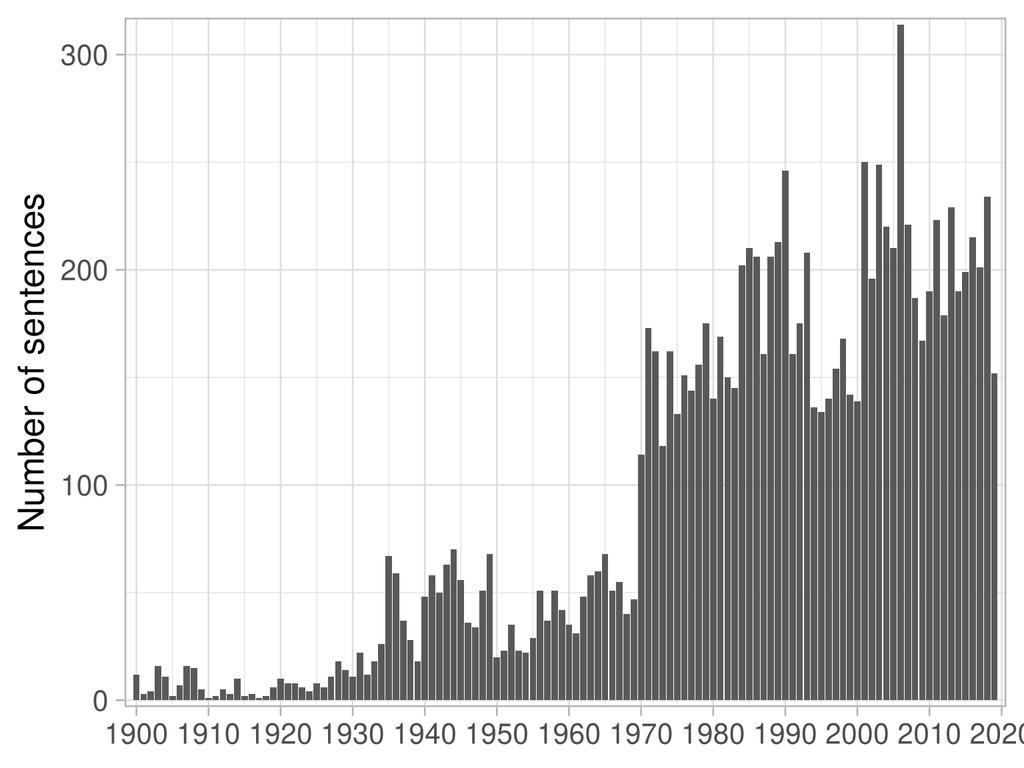

### Closest sentence from ‘rational’ and ‘rationality’ of the backbone community

| Sentence | Title | Year | Journal | Authors | Words Similarity |
| --- | --- | --- | --- | --- | --- |
| ‘Rational expectations and the theory of price movements.’ | [The Performance of Rice Markets in Bangladesh During the 1974 Famine](http://www.jstor.org/stable/2233466) | 1985 | The Economic Journal | Martin Ravallion | 0.813 |
| ‘Rational expectations and the theory of price movements.’ | [The Economic Role of Commodity Storage](http://www.jstor.org/stable/2232552) | 1982 | The Economic Journal | Brian D. Wright , Jeffrey C. Williams | 0.812 |
| Theoretical I IA Macrostochastic The statistical expectations of an RE principles rationality model are equivalent to the psychological expectations of rational market participants which dominate the … | [The Rational Expectations Tautologies](http://www.jstor.org/stable/4537731) | 1982 | Journal of Post Keynesian Economics | James R. Wible | 0.811 |
| I also add to the behavioral/ rationalist debate by demonstrating how a simple model with rational investors and asymmetric information can be applied to generate apparently behavioral phenomenon. | [Trade Generation, Reputation, and Sell-Side Analysts](http://www.jstor.org/stable/3694764) | 2005 | The Journal of Finance | Andrew R. Jackson | 0.809 |
| As noted in the introduction, a possible objection to models with imperfectly rational traders is that wealth may shift from foolish to rational traders until price setting is dominated by rational tr… | [Investor Psychology and Security Market under- and Overreactions](http://www.jstor.org/stable/117455) | 1998 | The Journal of Finance | Kent Daniel , David Hirshleifer , Avanidhar Subrahmanyam | 0.808 |
| This section tests another challenge to the market rationality hypothesis. | [Are Multiple Art Markets Rational?](http://www.jstor.org/stable/41810635) | 1997 | Journal of Cultural Economics | LESLIE P. SINGER, GARY A. LYNCH | 0.807 |
| ‘Rational expectations and the theory of price movements.’ | [Are UK Stock Prices Excessively Volatile? Trading Rules and Variance Bound Tests](http://www.jstor.org/stable/2234089) | 1989 | The Economic Journal | George Bulkley, Ian Tonks | 0.798 |
| The market economizes on the non-rational component of behavior, but it by no means eliminates the non-rational component. | [The Non-Rational Domain and the Limits of Economic Analysis](http://www.jstor.org/stable/1057009) | 1979 | Southern Economic Journal | Richard B. McKenzie | 0.796 |
| Following this distinction, the rational expectations equilibrium is treated in this paper as a “benchmark” for the analysis of market behavior when the market is not in the rational expectations equi… | [Towards an Understanding of Market Processes: Individual Expectations, Learning, and Convergence to Rational Expectations Equilibrium](http://www.jstor.org/stable/1810008) | 1982 | The American Economic Review | Roman Frydman | 0.793 |
| They show that a wide range of market events can be combined to form a very strong case against market rationality, albeit a circumstantial one. | [THE ASSESSMENT: THE NEW ECONOMY](http://www.jstor.org/stable/23606587) | 2002 | Oxford Review of Economic Policy | JONATHAN TEMPLE | 0.792 |
| The Rationality Struggle: Illustrations from Financial Markets. | [Index Funds, Financialization, and Commodity Futures Markets](http://www.jstor.org/stable/41237206) | 2011 | Applied Economic Perspectives and Policy | Scott H. Irwin , Dwight R. Sanders | 0.792 |
| The Efficient-Markets/Rational-Expectations Hypothesis. | [Using Financial Data to Measure Effects of Regulation](http://www.jstor.org/stable/725206) | 1981 | The Journal of Law & Economics | G. William Schwert | 0.789 |
| These results are consistent with the theoretical models which I have been describing and can be taken as support for the application of the rational expectations hypothesis to financial markets. | [Rational Expectations, Information and Asset Markets: An Introduction](http://www.jstor.org/stable/2663195) | 1985 | Oxford Economic Papers | Margaret Bray | 0.785 |
| “Rationality and the Decision to Invest in Economics,” J. | [The Flow of New Doctorates](http://www.jstor.org/stable/2727704) | 1992 | Journal of Economic Literature | Ronald G. Ehrenberg | 0.784 |
| Since, however, so many formal investigations have been published in the past which establish market failure due to rational behavior, we should now follow any conceivable route which promises the pos… | [Calculus of Consent: A Game-theoretic Perspective](http://www.jstor.org/stable/40751301) | 1990 | Journal of Institutional and Theoretical Economics (JITE) / Zeitschrift für die gesamte Staatswissenschaft | Urs Schweizer | 0.783 |
| The economic reasoning for the results on indeterminacy evolves as follows: rational investors know the behavior of the naive agents. | [On Forecasting Heterogeneity, Irrational Exuberance, and the Multiplicity of Rational Expectations Equilibria](http://www.jstor.org/stable/41794969) | 2002 | Journal of Economics | Mark Weder | 0.782 |
| The model describes market participants characterised by a boundedly rational behavior, and more im portantly by an idiosyncratic level of rationality. | [Strategic Market Games Quantal Response Equilibria](http://www.jstor.org/stable/25056029) | 2006 | Economic Theory | Dimitrios Voliotis | 0.780 |
| Rational expectations and the theory of price movements. | [The Gibson Paradox: A Cross-Country Analysis](http://www.jstor.org/stable/2554204) | 1984 | Economica | Gerald P. Dwyer, Jr. | 0.779 |
| Based on a reasonable interpretation of Thaler’s Groundhog Day argument, one could conclude that the collective rationality of markets is negatively related to the individual rationality of market dec… | [Can behavioral economists improve economic rationality?](http://www.jstor.org/stable/48720031) | 2018 | Public Choice | Dwight R. Lee, J. R. Clark | 0.779 |
| “Rationality, Price Risk, and Response.” | [Risk Behavior and Rational Expectations in the U.S. Broiler Market](http://www.jstor.org/stable/1242667) | 1989 | American Journal of Agricultural Economics | Satheesh V. Aradhyula, Matthew T. Holt | 0.777 |
| There is a growing number of theoretical contributions that analyze the performance of markets characterized by a mixture of rational and near-rational decision makers. | [Banking (Conservatively) with Optimists](http://www.jstor.org/stable/2556083) | 1999 | The RAND Journal of Economics | Michael Manove , A. Jorge Padilla | 0.777 |

### Closest sentences of the backbone community’s centroid

| Sentence | Title | Year | Journal | Authors | Centroid Similarity |
| --- | --- | --- | --- | --- | --- |
| It would appear that some of the assumptions which characterize this literature might be applicable to aspects of political markets. | [Politics as a Filter](http://www.jstor.org/stable/30023425) | 1981 | Public Choice | George Daly | 0.7836870 |
| As we have seen, the political process may be invoked because the market cannot express the ” collective ” demand for investment to benefit the future and because we may prefer the weights of some pol… | [The Social Time Preference Discount Rate in Cost Benefit Analysis](http://www.jstor.org/stable/2228484) | 1964 | The Economic Journal | M. S. Feldstein | 0.7384504 |
| Although in stock markets all agents’ expectations may be unbiased, they may or may not be unbiased in political markets. | [Some Evidence on the Effect of the Separation of Spending and Taxing Decisions](http://www.jstor.org/stable/1840433) | 1983 | Journal of Political Economy | Stanley L. Winer | 0.7341918 |
| While the market may be the place where businessmen invest the bulk of their funds, the “parameters” that mainstream economists are so prone to ignore frequently are established in the political arena… | [The Challenge of Radical Political Economics](http://www.jstor.org/stable/4224291) | 1974 | Journal of Economic Issues | Raymond S. Franklin, William K. Tabb | 0.7319587 |
| Changing the expected reaction of others will not affect the result, though if each individual believes that his own decision may affect the decisions of others, different results may be obtained.1 Su… | [The Nature of the Commodity ‘Health Care’ and its Efficient Allocation](http://www.jstor.org/stable/2662234) | 1971 | Oxford Economic Papers | A. J. Culyer | 0.7307050 |
| Though we do not question the veracity of Demsetz’s argument as applied to firms, we propose to show that it is not equally applicable to the political market. | [Brand Names and Barriers to Entry in Political Markets](http://www.jstor.org/stable/30024672) | 1986 | Public Choice | John R. Lott Jr. | 0.7278113 |
| Although all agents’ expectations may be unbiased in stock markets, they may or may not be unbiased in political markets. | [Some Evidence on the Effect of the Separation of Spending and Taxing Decisions](http://www.jstor.org/stable/1840433) | 1983 | Journal of Political Economy | Stanley L. Winer | 0.7233237 |
| Yet the leading behavioral economists exhibit far more interest in applying those biases to market decisions than to political decision-, and see irrational decisions making as another example of mark… | [Can behavioral economists improve economic rationality?](http://www.jstor.org/stable/48720031) | 2018 | Public Choice | Dwight R. Lee, J. R. Clark | 0.7211557 |
| The Normative Implications of Market Clearing Prices If economics customarily assumes away most of the implications of power, mainstream political science appears to begin by assuming that the distrib… | [Confronting Power in Economics: A Pragmatic Evaluation](http://www.jstor.org/stable/4224970) | 1980 | Journal of Economic Issues | Philip A. Klein | 0.7179175 |
| For large n the absolute values of ak and /3 cease to be important; the individual bases his vote for or against collective investment simply on the relative psychic value to him of a dollar of presen… | [The Social Rate of Discount and The Optimal Rate of Investment](http://www.jstor.org/stable/1879374) | 1963 | The Quarterly Journal of Economics | Stephen A. Marglin | 0.7105837 |
| Since the wise politician is assumed to maximize votes by doing what the majority prefers, then if we depart slightly from one original assumption and business investments have really become the most … | [Economic Elements in Municipal Zoning Decisions](http://www.jstor.org/stable/3144842) | 1963 | Land Economics | Otto A. Davis | 0.7053159 |
| We assume, as before, that at the time of constitutional choice the individual is wholly uncertain as to his own position in the market distribution that will emerge in the first period of the postcon… | [Political Constraints on Contractual Redistribution](http://www.jstor.org/stable/1816035) | 1974 | The American Economic Review | James M. Buchanan, Winston C. Bush | 0.6912424 |
| In principle, capital market imperfections and the government’s role can be affected by political processes, whereas the incentive effects highlighted in this article follow directly from individual p… | [ON THE TAXATION OF DURABLE GOODS](http://www.jstor.org/stable/45018874) | 2018 | International Economic Review | Sebastian Koehne | 0.6890371 |
| The resolution of these divergent preferences and consumption plans will, presumably, be accomplished through the use of some sort of intra-collective political process.27 But if the multiperiod prefe… | [Toward a Dynamic Model of the Yugoslav Firm](http://www.jstor.org/stable/133525) | 1971 | The Canadian Journal of Economics / Revue canadienne d’Economique | Eirik G. Furubotn | 0.6888977 |
| This conditioning of ours is mainly a result of the fact that we can only seldom free ourselves from the assumption of classical political economy - sometimes explicitly stated, sometimes only tacitly… | [PRICES, PROFITS, DEFICIT FINANCING. (The Case of the US Economy, 1968-1977)](http://www.jstor.org/stable/40728724) | 1979 | Acta Oeconomica | P. ERDÖS , F. MOLNÁR | 0.6868937 |

### Closest sentences of each kmean cluster’s centroid composing the backbone community

#### Top terms 2_16: professor_clark, abstinence, clark, capital, consumable (1900-1919)

| Sentence | Title | Year | Journal | Authors | Distance to Centroid |
| --- | --- | --- | --- | --- | --- |
| In the writer’s judgment, Professor Fisher has eliminated from his concept nothing less than the fundamental and distinctive notion of capital, the quality of being a surplus, which has always attache… | [The Fundamental Notion of Capital, Once More](http://www.jstor.org/stable/1884864) | 1904 | The Quarterly Journal of Economics | Charles A. Tuttle | 6.750335 |
| “3 In a succession of paragraphs he emphasises, quite in the spirit of the most approved modern treatises, but partly in opposition to most of the text-books of his day, the fact that wealth does not … | [On Some Neglected British Economists-II](http://www.jstor.org/stable/2221318) | 1903 | The Economic Journal | Edwin R. A. Seligman | 6.839300 |
| Among such essays showing the awakened interest in the concept of capital must be classed the articles from Professor Fisher’s hands ten years a.go. | [The Nature of Capital and Income](http://www.jstor.org/stable/1817446) | 1907 | Journal of Political Economy | Frank A. Fetter | 6.976639 |
| What needs to be emphasized for our present purpose is that if an individual is to increase his productive power by the use of capital he must, under primitive conditions where exchange does not exist… | [Commercial Banking and Capital Formation: IV](http://www.jstor.org/stable/1822000) | 1918 | Journal of Political Economy | H. G. Moulton | 7.016596 |
| He recognizes the scientific importance of these conceptions, which have resulted from profound analyses of economic phenomena; but he characterizes the application of the term “capital” to them as ar… | [The Real Capital Concept](http://www.jstor.org/stable/1882775) | 1903 | The Quarterly Journal of Economics | Charles A. Tuttle | 7.037351 |

#### Top terms 2_27: investment, capitalization, capital, reproduction, abstinence (1920-1939)

| Sentence | Title | Year | Journal | Authors | Distance to Centroid |
| --- | --- | --- | --- | --- | --- |
| “4 This clearly assumes the existence of a separate substance of capital apart from its manifestation in concrete capital goods, a”fund” of a mystical quantity which cannot be described or defined but… | [The Mythology of Capital](http://www.jstor.org/stable/1885022) | 1936 | The Quarterly Journal of Economics | F. A. v. Hayek | 7.709347 |
| tions of factors, has never been more clearly or persuasively argued than by Professor Knight himself in his earlier writings.34 It is a proposition on which, ultimately, not only Bohm-Bawerk and the … | [On the Theory of Capital: A Rejoinder to Professor Knight](http://www.jstor.org/stable/1907149) | 1938 | Econometrica | Nicholas Kaldor | 7.727531 |
| What is “really” invested in an individual capital good is this sacrificed final value or want satisfaction.6 But it is simply contrary to the essential and obvious facts to trace even an individual c… | [The Theory of Investment Once More: Mr. Boulding and the Austrians](http://www.jstor.org/stable/1882342) | 1935 | The Quarterly Journal of Economics | Frank H. Knight | 7.738199 |
| omists of the doctrine of their great teacher; for the same writer proceeds to analyze the residue “which the economists usually speak of as ‘profits of stock,’” and finds it made up of four parts, on… | [The Entrepreneur Function in Economic Literature](http://www.jstor.org/stable/1820869) | 1927 | Journal of Political Economy | Charles A. Tuttle | 7.748357 |
| The “manifestations of capital wastage” are, in his sense, “static adjustments”; and not “dynamic changes” It is no use, therefore, for the economist to content himself with being “inclined to believe… | [“The Nature and Significance of Economic Science” in Recent Discussion](http://www.jstor.org/stable/1883978) | 1933 | The Quarterly Journal of Economics | R. W. Souter | 7.753274 |

#### Top terms 2_38: physiocratic, investment, consumers_surplus, liquidity_preference, stagnation (1940-1949)

| Sentence | Title | Year | Journal | Authors | Distance to Centroid |
| --- | --- | --- | --- | --- | --- |
| Knight does not explain the second half of his statement, that his proposal makes the theory of consumption logically parallel with the theory of production, nor does he explain why this would be desi… | [Professor Knight and the Theory of Demand](http://www.jstor.org/stable/1825792) | 1946 | Journal of Political Economy | Robert L. Bishop | 7.615466 |
| iii of this articl Canadian Journal of Economtics and Political Science century virtues, frugality and thrift, and accepted the current opinion that growth of capital depends primarily, not upon scien… | [Malthus’s Total Population Theory: A Restatement and Reappraisal](http://www.jstor.org/stable/137380) | 1945 | The Canadian Journal of Economics and Political Science / Revue canadienne d’Economique et de Science politique | Joseph J. Spengler | 7.864294 |
| 14 III Perhaps enough has been said about, and quoted from, Professor Schumpeter’s famous article to show the intimate relation between his theory of money and his general equilibrium theory. | [Monetary, Equilibrium, and Business-Cycle Theory](http://www.jstor.org/stable/1924550) | 1943 | The Review of Economics and Statistics | Wolfgang F. Stolper | 7.982865 |
| The thought plainly is of the present moment, when, by saving, productive agents are diverted2” from the creation of consumables to that of additional capital agents, entirely ignoring the future incr… | [Lauderdale’s Oversaving Theory](http://www.jstor.org/stable/1811441) | 1945 | The American Economic Review | Frank Albert Fetter | 7.998535 |
| The problem of capital accumulation becoming excessive is inseparable from the problem of changeability of relative prices and of the changeability of a and s. IV It follows that Domar’s remedy of “so… | [The Problem of Capital Accumulation](http://www.jstor.org/stable/1816594) | 1949 | The American Economic Review | Ernest H. Stern | 8.022855 |

#### Top terms 2_51: investment, investment_decisions, acceleration, invest, investment_decision (1950-1959)

| Sentence | Title | Year | Journal | Authors | Distance to Centroid |
| --- | --- | --- | --- | --- | --- |
| It is an implication of this analysis, though it cannot be pursued here in detail, that solutions to the problem of investment decision recently proposed by Boulding, Samuelson, Scitovsky, and the Lut… | [On the Theory of Optimal Investment Decision](http://www.jstor.org/stable/1827424) | 1958 | Journal of Political Economy | J. Hirshleifer | 7.391618 |
| This assumption regarding Investment is not necessarily valid. | [A Graphical Analysis of the Foreign Trade Multiplier](http://www.jstor.org/stable/2226899) | 1952 | The Economic Journal | Romney Robinson | 7.478613 |
| Indeed the main purpose of ‘overhead’ investments, it is obvious, is primarily to create conditions favourable for other investments to be undertaken, which means that, though the economies created by… | [APPLICATION OF INVESTMENT CRITERIA IN THE CHOICE BETWEEN PROJECTS](http://www.jstor.org/stable/29793054) | 1956 | Indian Economic Review | K. N. Raj | 7.532333 |
| The reasoning is that, in certain categories of investment considered essential, there is likely to be no such choice on account of technical factors, and that the capital-output DHA? | [SOME ASPECTS OF TECHNICAL PROGRESS IN SMALL SCALE INDUSTRIES](http://www.jstor.org/stable/29793037) | 1956 | Indian Economic Review | P. N. Dhar | 7.732564 |
| This article is concerned with some difficulties involved in the explanation presented by Professor G. L. S. Shackle in his book Expectation in Economics.2 When, in conditions of uncertainty, an inves… | [Investment, Uncertainty and Expectations](http://www.jstor.org/stable/2296288) | 1954 | The Review of Economic Studies | R. A. D. Egerton | 7.881544 |

#### Top terms 2_68: investment, investment_decision, investment_decisions, public_investment, projects (1960-1969)

| Sentence | Title | Year | Journal | Authors | Distance to Centroid |
| --- | --- | --- | --- | --- | --- |
| A POSTSCRIPT ABOUT INVESTMENT It may be of interest that two assumptions about investment decisions in addition to the one made in the main text would produce essentially the same results. | [A Theory of Investment, Distribution, and Employment](http://www.jstor.org/stable/2662467) | 1965 | Oxford Economic Papers | W. A. Eltis | 7.056524 |
| In Section I we refer to earlier studies on this problem and formulate our hypothesis of investment behaviour. | [An Analysis of the Effects of Investment Incentives on Investment Behaviour in the British Economy](http://www.jstor.org/stable/2552377) | 1969 | Economica | R. Agarwala , G. C. Goodson | 7.224175 |
| Moreover, sin In order to explore this problem in a more sophisticated and presumably more realistic’ context we now turn to a neoclassical model of investment which has enjoyed substantial popularity… | [The Use of Endogenous Variables in Dynamic Models of Investment](http://www.jstor.org/stable/1885451) | 1969 | The Quarterly Journal of Economics | John P. Gould | 7.436074 |
| The present study attempts to advance our knowledge of the investment decision in essentially two ways. | [Manufacturers’ Capital Appropriations as a Measure of Investment Decisions: An Econometric Study of Quarterly Time Series](http://www.jstor.org/stable/2977840) | 1966 | The Journal of Finance | Reynold M. Sachs | 7.446770 |
| The present study attempts to advance our knowledge of the investment decision in essentially two ways. | [Abstracts of Doctoral Dissertations Econometric Abstracts](http://www.jstor.org/stable/25602676) | 1966 | The American Economist | NULL | 7.446771 |

#### Top terms 2_82: investment, investment_decisions, investment_decision, public_investment, investment_behavior (1970-1979)

| Sentence | Title | Year | Journal | Authors | Distance to Centroid |
| --- | --- | --- | --- | --- | --- |
| I wish especially to acknowledge the advice and encouragement of Dale W. Jorgenson, most particularly in connection with my discussion of his extensive empirical work on investment. | [Lags in Economic Behavior](http://www.jstor.org/stable/1909403) | 1972 | Econometrica | Marc Nerlove | 7.332702 |
| “On the Role of Expectations in the Pure Iheory of Investment.” | [The Influence of Uncertainty on Investment](http://www.jstor.org/stable/2231832) | 1977 | The Economic Journal | S. J. Nickell | 7.347986 |
| This result has bearing on the controversy surrounding the neo-classical theory of investment. | [Technological Change and Factor Substitution in the United States: 1929- 1967](http://www.jstor.org/stable/2526339) | 1978 | International Economic Review | Joseph P. Kalt | 7.420937 |
| William Brainard: I want to comment on James Tobin’s theory of investment which Hall describes as a major competitor to Jorgenson’s theoretical framework, and to offer some observations about the Jorg… | [Investment, Interest Rates, and the Effects of Stabilization Policies](http://www.jstor.org/stable/2534257) | 1977 | Brookings Papers on Economic Activity | Robert E. Hall , Christopher A. Sims, Franco Modigliani , William Brainard | 7.699292 |
| One important point is dealt with in contradictory ways by Taubman and Brannon inefficiency in past investment does not, as Taubman asserts, necessarily imply inefficiency at the margin in new investm… | [Session Topic: Tax Depreciation Reform: Discussion](http://www.jstor.org/stable/2978496) | 1972 | The Journal of Finance | Robert M. Coen, Martin David | 7.721609 |

#### Top terms 2_87: market_efficiency, market_system, efficient_markets, market_failure, markets_theory (1970-1979)

| Sentence | Title | Year | Journal | Authors | Distance to Centroid |
| --- | --- | --- | --- | --- | --- |
| 9 On the question of markets, cf. | [The Role of Rural Domestic Industry in Bohemia in the Eighteenth Century](http://www.jstor.org/stable/2594203) | 1974 | The Economic History Review | Arnošt Klíma | 7.112505 |
| As no one knows better than the author of The Worldly Philosophers, our profession’s obsession with “the market” goes back at least to the time of Thomas Aquinas and his principle of “just price,” and… | [[Comment on Heilbroner]](http://www.jstor.org/stable/4224096) | 1971 | Journal of Economic Issues | C. E. Ayres | 7.357068 |
| We begin by briefly reviewing the linear market model. | [Duration and Risk Assessment for Bonds and Common Stocks](http://www.jstor.org/stable/2326661) | 1975 | The Journal of Finance | John A. Boquist , George A. Racette , Gary G. Schlarbaum | 7.558193 |
| DISCUSSION ENRIQUE R. ARZAC*: Professor Umstead presents an articulate challenge to the efficient market hypothesis in its semi-strong form. | [Session Topic: Investments–Empirical Studies: Discussion](http://www.jstor.org/stable/2326778) | 1977 | The Journal of Finance | Enrique R. Arzac | 7.626197 |
| Our earlier model of the operation of a market economy was based on such a narrow view and must now be generalized. | [Economic Policy Design: Principles and Urban Applications](http://www.jstor.org/stable/40324603) | 1974 | Eastern Economic Journal | Thomas Vietorisz | 7.657880 |

#### Top terms 2_102: rational_expectations, asset, option_pricing, efficient_markets, stock_market (1980-1989)

| Sentence | Title | Year | Journal | Authors | Distance to Centroid |
| --- | --- | --- | --- | --- | --- |
| These results are consistent with the theoretical models which I have been describing and can be taken as support for the application of the rational expectations hypothesis to financial markets. | [Rational Expectations, Information and Asset Markets: An Introduction](http://www.jstor.org/stable/2663195) | 1985 | Oxford Economic Papers | Margaret Bray | 6.983038 |
| Following this distinction, the rational expectations equilibrium is treated in this paper as a “benchmark” for the analysis of market behavior when the market is not in the rational expectations equi… | [Towards an Understanding of Market Processes: Individual Expectations, Learning, and Convergence to Rational Expectations Equilibrium](http://www.jstor.org/stable/1810008) | 1982 | The American Economic Review | Roman Frydman | 7.230933 |
| Much of the recent theoretical work on asset markets has been concerned with investigating the circumstances under which a rational expectations equilibrium exists, and is informationally efficient. | [Rational Expectations, Information and Asset Markets: An Introduction](http://www.jstor.org/stable/2663195) | 1985 | Oxford Economic Papers | Margaret Bray | 7.252787 |
| Recent theoretical work on asset markets, based on the rational expectations hypothesis, has argued that they may have an additional informational role. | [Rational Expectations, Information and Asset Markets: An Introduction](http://www.jstor.org/stable/2663195) | 1985 | Oxford Economic Papers | Margaret Bray | 7.272654 |
| A Reexamination of the Rationality of the Livingston Price Expectations A Note by John R. Schroeter and Scott L. Smith 1. | [A Reexamination of the Rationality of the Livingston Price Expectations: Note](http://www.jstor.org/stable/1992208) | 1986 | Journal of Money, Credit and Banking | John R. Schroeter, Scott L. Smith | 7.294491 |

#### Top terms 2_117: traders, investors, rational_investors, asset, rational_expectations (1990-1999)

| Sentence | Title | Year | Journal | Authors | Distance to Centroid |
| --- | --- | --- | --- | --- | --- |
| S. & Watson, M.: Bubbles, rational expectations and financial markets. | [Mean Reversion in Stock Prices: Implications from a Production Based Asset Pricing Model](http://www.jstor.org/stable/3440666) | 1994 | The Scandinavian Journal of Economics | Parantap Basu , Hrishikesh D. Vinod | 7.125062 |
| Overall, our analysis suggests that near-rational behaviour may be an important force on financial markets. | [Near-Rational Behaviour and Financial Market Fluctuations](http://www.jstor.org/stable/2234477) | 1993 | The Economic Journal | Yong Wang | 7.209959 |
| Rational investors may not be sufficiently numerous to insulate market prices from the irrational ones. | [The Value and Performance of U.S. Corporations](http://www.jstor.org/stable/2534602) | 1993 | Brookings Papers on Economic Activity | Bronwyn H. Hall , Robert E. Hall , John Heaton , N. Gregory Mankiw | 7.335583 |
| Financial markets are probably more rational than they sometimes appear. | [THEORIES OF FINANCIAL FRAGILITY](http://www.jstor.org/stable/23247869) | 1992 | Giornale degli Economisti e Annali di Economia | Harald A. Benink | 7.352250 |
| This view was not based on the predictions of the models considered here, and it is indeed questionable that it could be supported by any generally accepted positive model of the market, but later in … | [Collusive Equilibrium in the Great Salt Duopoly](http://www.jstor.org/stable/2234704) | 1993 | The Economic Journal | Ray Rees | 7.370612 |

#### Top terms 2_135: investors, traders, rational_investors, asset, irrational_traders (2000-2009)

| Sentence | Title | Year | Journal | Authors | Distance to Centroid |
| --- | --- | --- | --- | --- | --- |
| At first glance, one might be tempted to conclude that our results support the behavioral paradigm, in which investors suffer from cognitive biases that prevent Bayesian updating. | [The Long-Run Performance Following Dividend Initiations and Resumptions: Underreaction or Product of Chance?](http://www.jstor.org/stable/2697761) | 2002 | The Journal of Finance | Rodney D. Boehme, Sorin M. Sorescu | 7.004465 |
| While our analysis assumes full rationality of investors, the recent literature in behavioral finance implies that expectational errors could be caused by deviations from rationality, such as overconf… | [Higher Order Expectations in Asset Pricing](http://www.jstor.org/stable/25096284) | 2008 | Journal of Money, Credit and Banking | Philippe Bacchetta, Eric Van Wincoop | 7.204414 |
| The Stock Market A premise of this paper is the rationality of the stock market, or, more precisely, of securities markets generally. | [E-Capital: The Link between the Stock Market and the Labor Market in the 1990s](http://www.jstor.org/stable/2667356) | 2000 | Brookings Papers on Economic Activity | Robert E. Hall , Jason G. Cummins, Owen A. Lamont | 7.212318 |
| THE IDEA THAT REAL-WORLD INVESTORS MAY NOT BE fully rational is an important influence on studies of modern asset pricing. | [The Limits of Investor Behavior](http://www.jstor.org/stable/3699340) | 2006 | The Journal of Finance | Mark Loewenstein , Gregory A. Willard | 7.221958 |
| The deviation from rational expectations is related to several papers that resolve asset-pricing puzzles with departures from rationality, including Stephen Cecchetti et al. | [The Natural Rate of Q](http://www.jstor.org/stable/3083384) | 2002 | The American Economic Review | Bill Dupor | 7.328264 |

#### Top terms 2_143: investors, asset, asset_pricing, rational_investors, financial_markets (2010-2019)

| Sentence | Title | Year | Journal | Authors | Distance to Centroid |
| --- | --- | --- | --- | --- | --- |
| Markets Are Not Fully Rational. | [RETHINKING MACROECONOMICS: WHAT FAILED, AND HOW TO REPAIR IT](http://www.jstor.org/stable/25836083) | 2011 | Journal of the European Economic Association | Joseph E. Stiglitz | 7.145983 |
| This finding poses a challenge to the hypothesis that investors are rational, because it suggests that investors are making mistakes: they are throwing away money buying overpriced securities that sub… | [Overconfident Investors, Predictable Returns, and Excessive Trading](http://www.jstor.org/stable/43611011) | 2015 | The Journal of Economic Perspectives | Kent Daniel , David Hirshleifer | 7.196330 |
| The Rationality Struggle: Illustrations from Financial Markets. | [Index Funds, Financialization, and Commodity Futures Markets](http://www.jstor.org/stable/41237206) | 2011 | Applied Economic Perspectives and Policy | Scott H. Irwin , Dwight R. Sanders | 7.241318 |
| More importantly, Harrison and Kreps show that if beliefs fluctuate over time, an optimist is willing to pay more than his already optimistic belief of asset fundamentals, anticipating the possibility… | [The Chinese Warrants Bubble](http://www.jstor.org/stable/23045656) | 2011 | The American Economic Review | Wei Xiong, Jialin Yu | 7.270187 |
| One key element in the theories coming out of this research is that people do not possess the full set of information assumed in the standard asset price model with rational expectations. | [Bubbles Tomorrow and Bubbles Yesterday, but Never Bubbles Today?](http://www.jstor.org/stable/43677853) | 2013 | Business Economics | JOHN C. WILLIAMS | 7.291537 |

### Top articles (most sentences) of the backbone cluster

| Title | Year | Journal | Authors | Number sentences | Words Similarity |
| --- | --- | --- | --- | --- | --- |
| [The Price Impact and Survival of Irrational Traders](http://www.jstor.org/stable/3699339) | 2006 | The Journal of Finance | Leonid Kogan , Stephen A. Ross , Jiang Wang , Mark M. Westerfield | 46 | 0.630 |
| [Positive Feedback Investment Strategies and Destabilizing Rational Speculation](http://www.jstor.org/stable/2328662) | 1990 | The Journal of Finance | J. Bradford de Long, Andrei Shleifer , Lawrence H. Summers, Robert J. Waldmann | 26 | 0.622 |
| [Investor Psychology and Asset Pricing](http://www.jstor.org/stable/2697808) | 2001 | The Journal of Finance | David Hirshleifer | 24 | 0.629 |
| [Clearly Irrational Financial Market Behavior: Evidence from the Early Exercise of Exchange Traded Stock Options](http://www.jstor.org/stable/3094481) | 2003 | The Journal of Finance | Allen M. Poteshman, Vitaly Serbin | 23 | 0.618 |
| [Empirical Asset Pricing: Eugene Fama, Lars Peter Hansen, and Robert Shiller](http://www.jstor.org/stable/43673655) | 2014 | The Scandinavian Journal of Economics | John Y. Campbell | 23 | 0.631 |
| [The Maintenance of Capital](http://www.jstor.org/stable/2548607) | 1935 | Economica | F. A. von Hayek | 21 | 0.607 |
| [Stock Prices and Social Dynamics](http://www.jstor.org/stable/2534436) | 1984 | Brookings Papers on Economic Activity | Robert J. Shiller , Stanley Fischer , Benjamin M. Friedman | 21 | 0.618 |
| [Are Judgment Errors Reflected in Market Prices and Allocations? Experimental Evidence Based on the Monty Hall Problem](http://www.jstor.org/stable/3694728) | 2004 | The Journal of Finance | Brian D. Kluger, Steve B. Wyatt | 19 | 0.641 |
| [The Investment Decision in Our System of Capital Formation](http://www.jstor.org/stable/4379272) | 1964 | Eastern European Economics | Drago Gorupić | 18 | 0.608 |
| [The Concept of Information, Intractable Uncertainty, and the Current State of the “Efficient Markets” Theory: A Post Keynesian View](http://www.jstor.org/stable/4538397) | 1994 | Journal of Post Keynesian Economics | Murray Glickman | 18 | 0.642 |
| [If You’re so Smart, Why Aren’t You Rich? Belief Selection in Complete and Incomplete Markets](http://www.jstor.org/stable/3805913) | 2006 | Econometrica | Lawrence Blume, David Easley | 18 | 0.648 |
| [HERDING AND CONTRARIAN BEHAVIOR IN FINANCIAL MARKETS](http://www.jstor.org/stable/41237854) | 2011 | Econometrica | Andreas Park , Hamid Sabourian | 18 | 0.604 |
| [The Mythology of Capital](http://www.jstor.org/stable/1885022) | 1936 | The Quarterly Journal of Economics | F. A. v. Hayek | 17 | 0.612 |
| [Efficient Capital Markets and Martingales](http://www.jstor.org/stable/2727024) | 1989 | Journal of Economic Literature | Stephen F. LeRoy | 17 | 0.627 |
| [Rational Asset-Price Movements Without News](http://www.jstor.org/stable/2117551) | 1993 | The American Economic Review | David Romer | 17 | 0.652 |

### Top articles (most sentences) of the cluster for each time window

#### Top articles for 2_16: professor_clark, abstinence, clark, capital, consumable (1900-1919)

| Title | Year | Journal | Authors | Number sentences | Words Similarity |
| --- | --- | --- | --- | --- | --- |
| [Recent Discussion of the Capital Concept](http://www.jstor.org/stable/1885860) | 1900 | The Quarterly Journal of Economics | Frank A. Fetter | 11 | 0.625 |
| [The Real Capital Concept](http://www.jstor.org/stable/1882775) | 1903 | The Quarterly Journal of Economics | Charles A. Tuttle | 9 | 0.632 |
| [Precedents for Defining Capital](http://www.jstor.org/stable/1884076) | 1904 | The Quarterly Journal of Economics | Irving Fisher | 5 | 0.627 |
| [Capital and Interest Once More: I. Capital Vs. Capital Goods](http://www.jstor.org/stable/1883748) | 1906 | The Quarterly Journal of Economics | E. Böhm-Bawerk | 5 | 0.620 |
| [The Nature of Capital and Income](http://www.jstor.org/stable/1817446) | 1907 | Journal of Political Economy | Frank A. Fetter | 5 | 0.616 |
| [Capital as a Competitive Concept](http://www.jstor.org/stable/1817716) | 1904 | Journal of Political Economy | H. J. Davenport | 4 | 0.640 |
| [Capital and Interest Once More: II. A Relapse to the Productivity Theory](http://www.jstor.org/stable/1883433) | 1907 | The Quarterly Journal of Economics | E. Böhm-Bawerk | 4 | 0.612 |
| [Interest Theories, Old and New](http://www.jstor.org/stable/1804984) | 1914 | The American Economic Review | Frank A. Fetter | 4 | 0.602 |
| [On Some Neglected British Economists-II](http://www.jstor.org/stable/2221318) | 1903 | The Economic Journal | Edwin R. A. Seligman | 3 | 0.643 |
| [Concerning the Nature of Capital: A Reply](http://www.jstor.org/stable/1884903) | 1907 | The Quarterly Journal of Economics | John Bates Clark | 3 | 0.615 |

#### Top articles for 2_27: investment, capitalization, capital, reproduction, abstinence (1920-1939)

| Title | Year | Journal | Authors | Number sentences | Words Similarity |
| --- | --- | --- | --- | --- | --- |
| [The Maintenance of Capital](http://www.jstor.org/stable/2548607) | 1935 | Economica | F. A. von Hayek | 21 | 0.607 |
| [The Mythology of Capital](http://www.jstor.org/stable/1885022) | 1936 | The Quarterly Journal of Economics | F. A. v. Hayek | 17 | 0.612 |
| [The Quantity of Capital and the Rate of Interest: I](http://www.jstor.org/stable/1823196) | 1936 | Journal of Political Economy | Frank H. Knight | 15 | 0.605 |
| [The Theory of Investment Once More: Mr. Boulding and the Austrians](http://www.jstor.org/stable/1882342) | 1935 | The Quarterly Journal of Economics | Frank H. Knight | 8 | 0.611 |
| [Capital, Time, and the Interest Rate](http://www.jstor.org/stable/2548804) | 1934 | Economica | Frank H. Knight | 6 | 0.588 |
| [Professor Hayek and the Theory of Investment](http://www.jstor.org/stable/2224581) | 1935 | The Economic Journal | Frank H. Knight | 5 | 0.609 |
| [The Rate of Return to Capital](http://www.jstor.org/stable/1812652) | 1935 | The American Economic Review | G. A. Kleene | 5 | 0.602 |
| [On the Theory of Capital: In Reply to Mr. Kaldor](http://www.jstor.org/stable/1910085) | 1938 | Econometrica | Frank H. Knight | 5 | 0.622 |
| [On the Theory of Capital: A Rejoinder to Professor Knight](http://www.jstor.org/stable/1907149) | 1938 | Econometrica | Nicholas Kaldor | 5 | 0.596 |
| [Marshall on Rent](http://www.jstor.org/stable/2223636) | 1930 | The Economic Journal | F. W. Ogilvie | 4 | 0.613 |

#### Top articles for 2_38: physiocratic, investment, consumers_surplus, liquidity_preference, stagnation (1940-1949)

| Title | Year | Journal | Authors | Number sentences | Words Similarity |
| --- | --- | --- | --- | --- | --- |
| [Diminishing Returns from Investment](http://www.jstor.org/stable/1830979) | 1944 | Journal of Political Economy | Frank H. Knight | 11 | 0.625 |
| [Professor Knight on Limits to the Use of Capital](http://www.jstor.org/stable/1882845) | 1944 | The Quarterly Journal of Economics | David McCord Wright | 10 | 0.614 |
| [Malthus’s General Theory of Employment and the Post-Napoleonic Depressions](http://www.jstor.org/stable/2113496) | 1943 | The Journal of Economic History | James J. O’Leary | 8 | 0.597 |
| [The Nature of Interest-Rates](http://www.jstor.org/stable/2661940) | 1949 | Oxford Economic Papers | G. L. S. Shackle | 7 | 0.625 |
| [Professor Mises and the Theory of Capital](http://www.jstor.org/stable/2550107) | 1941 | Economica | F. H. Knight | 6 | 0.632 |
| [The Primary Functions of Money and their Consummation in Monetary Policy](http://www.jstor.org/stable/1814476) | 1940 | The American Economic Review | Frank D. Graham | 5 | 0.596 |
| [Myrdal’s Analysis of Monetary Equilibrium](http://www.jstor.org/stable/2663487) | 1945 | Oxford Economic Papers | G. L. S. Shackle | 5 | 0.606 |
| [The Physiocrats and Say’s Law of Markets. II](http://www.jstor.org/stable/1826905) | 1945 | Journal of Political Economy | Joseph J. Spengler | 5 | 0.589 |
| [“Full Utilization,” Equilibrium, and the Expansion of Production](http://www.jstor.org/stable/1884721) | 1940 | The Quarterly Journal of Economics | A. B. Wolfe | 4 | 0.599 |
| [Professor Hayek on the Pure Theory of Capital](http://www.jstor.org/stable/1803239) | 1941 | The American Economic Review | Arthur Smithies | 4 | 0.607 |

#### Top articles for 2_51: investment, investment_decisions, acceleration, invest, investment_decision (1950-1959)

| Title | Year | Journal | Authors | Number sentences | Words Similarity |
| --- | --- | --- | --- | --- | --- |
| [The Acceleration Principle and the Theory of Investment: A Survey](http://www.jstor.org/stable/2550657) | 1952 | Economica | A. D. Knox | 7 | 0.589 |
| [APPLICATION OF INVESTMENT CRITERIA IN THE CHOICE BETWEEN PROJECTS](http://www.jstor.org/stable/29793054) | 1956 | Indian Economic Review | K. N. Raj | 7 | 0.593 |
| [The Disaggregation of Investment in the Study of Economic Growth](http://www.jstor.org/stable/2227967) | 1956 | The Economic Journal | A. J. Youngson | 6 | 0.622 |
| [Saving, Investment, and Stability](http://www.jstor.org/stable/1910663) | 1956 | The American Economic Review | William A. Salant | 5 | 0.607 |
| [Investment Alternatives in Soviet Economic Theory](http://www.jstor.org/stable/1825962) | 1952 | Journal of Political Economy | Norman Kaplan | 4 | 0.616 |
| [Industrial Investment Decisions: A Comparative Analysis](http://www.jstor.org/stable/2114427) | 1955 | The Journal of Economic History | Henry G. Aubrey | 4 | 0.625 |
| [The Optimum Rate of Investment](http://www.jstor.org/stable/2227285) | 1958 | The Economic Journal | Branko Horvat | 4 | 0.666 |
| [Accelerated Investment as a Force in Economic Development](http://www.jstor.org/stable/1884332) | 1958 | The Quarterly Journal of Economics | Howard S. Ellis | 4 | 0.607 |
| [International Specialization and the Concept of Balanced Growth](http://www.jstor.org/stable/1880594) | 1958 | The Quarterly Journal of Economics | John Sheahan | 4 | 0.591 |
| [Can Individual Investors be Induced to Furnish More Equity Capital?](http://www.jstor.org/stable/2975406) | 1950 | The Journal of Finance | Lewis A. Froman | 3 | 0.592 |

#### Top articles for 2_68: investment, investment_decision, investment_decisions, public_investment, projects (1960-1969)

| Title | Year | Journal | Authors | Number sentences | Words Similarity |
| --- | --- | --- | --- | --- | --- |
| [The Investment Decision in Our System of Capital Formation](http://www.jstor.org/stable/4379272) | 1964 | Eastern European Economics | Drago Gorupić | 18 | 0.608 |
| [Uncertainty, Likelihoods and Investment Decisions](http://www.jstor.org/stable/1884131) | 1960 | The Quarterly Journal of Economics | James W. Angell | 11 | 0.628 |
| [Some Reflexions on the Theories of Choice between Alternative Investment Opportunities](http://www.jstor.org/stable/40436564) | 1967 | Weltwirtschaftliches Archiv | Tönu Puu | 9 | 0.614 |
| [Ideal and Reality in the Choice between Alternative Techniques](http://www.jstor.org/stable/2662573) | 1964 | Oxford Economic Papers | Ronald L. Meek | 8 | 0.601 |
| [Cost-Benefit Analysis: A Survey](http://www.jstor.org/stable/2229670) | 1965 | The Economic Journal | A. R. Prest, R. Turvey | 8 | 0.616 |
| [The Social Rate of Discount and The Optimal Rate of Investment](http://www.jstor.org/stable/1879374) | 1963 | The Quarterly Journal of Economics | Stephen A. Marglin | 6 | 0.604 |
| [Capital Appropriations and the Accelerator](http://www.jstor.org/stable/1924060) | 1965 | The Review of Economics and Statistics | Albert Gailord Hart | 6 | 0.610 |
| [Investment Effectiveness and Balanced Development of the National Economy](http://www.jstor.org/stable/4379251) | 1963 | Eastern European Economics | József D. Szabó | 5 | 0.595 |
| [A Theory of Investment, Distribution, and Employment](http://www.jstor.org/stable/2662467) | 1965 | Oxford Economic Papers | W. A. Eltis | 5 | 0.608 |
| [Funds, Investment and Multiplier](http://www.jstor.org/stable/40434950) | 1962 | Weltwirtschaftliches Archiv | Masaichi Mizuno | 4 | 0.607 |

#### Top articles for 2_82: investment, investment_decisions, investment_decision, public_investment, investment_behavior (1970-1979)

| Title | Year | Journal | Authors | Number sentences | Words Similarity |
| --- | --- | --- | --- | --- | --- |
| [Uncertainty, Information and Investment Decisions](http://www.jstor.org/stable/2325741) | 1971 | The Journal of Finance | R. G. E. Smith | 9 | 0.599 |
| [Notes on consumption, investment and effective demand: I](http://www.jstor.org/stable/23596466) | 1978 | Cambridge Journal of Economics | Pierangelo Garegnani | 8 | 0.610 |
| [Investment Decisions in the Decentralized Sphere](http://www.jstor.org/stable/4379479) | 1974 | Eastern European Economics | László Bukta, George Hajdu | 7 | 0.615 |
| [The Revolutionary Character of Post-Keynesian Economics](http://www.jstor.org/stable/4224617) | 1977 | Journal of Economic Issues | Nina Shapiro | 7 | 0.611 |
| [Investment, Interest Rates, and the Effects of Stabilization Policies](http://www.jstor.org/stable/2534257) | 1977 | Brookings Papers on Economic Activity | Robert E. Hall , Christopher A. Sims, Franco Modigliani , William Brainard | 7 | 0.608 |
| [Corporate Investment: Does Market Valuation Matter in the Aggregate?](http://www.jstor.org/stable/2534406) | 1977 | Brookings Papers on Economic Activity | George M. von Furstenberg, Michael C. Lovell , James Tobin | 7 | 0.605 |
| [Investment Dynamics of a Two-Sector Production Model](http://www.jstor.org/stable/41797440) | 1972 | Zeitschrift für Nationalökonomie / Journal of Economics | Th. T. Sekine | 6 | 0.607 |
| [Uncertainty and the Evaluation of Public Investment Decisions: Comment](http://www.jstor.org/stable/1821489) | 1972 | The American Economic Review | E. J. Mishan | 6 | 0.602 |
| [INVESTMENT EQUILIBRIUM: MECHANISMS OF CONTROL AND DECISION](http://www.jstor.org/stable/40728022) | 1971 | Acta Oeconomica | J. Drecin | 5 | 0.604 |
| [THE OPTIMAL RATE OF GROWTH OF THE CAPITAL STOCK](http://www.jstor.org/stable/40728054) | 1972 | Acta Oeconomica | L. Mihályffy , Gy. Szakolczai | 4 | 0.643 |

#### Top articles for 2_87: market_efficiency, market_system, efficient_markets, market_failure, markets_theory (1970-1979)

| Title | Year | Journal | Authors | Number sentences | Words Similarity |
| --- | --- | --- | --- | --- | --- |
| [The Folklore of the Market: An Inquiry into the Economic Doctrines of the Chicago School](http://www.jstor.org/stable/4224459) | 1975 | Journal of Economic Issues | Ezra J. Mishan | 8 | 0.604 |
| [Rational Expectations in the Macro Model](http://www.jstor.org/stable/2534381) | 1976 | Brookings Papers on Economic Activity | William Poole , Edmund S. Phelps, Martin N. Baily | 8 | 0.642 |
| [Power and Illusion in the Marketplace: Institutions and Technology](http://www.jstor.org/stable/4224358) | 1974 | Journal of Economic Issues | Thomas R. De Gregori | 6 | 0.618 |
| [Entrepreneurship, Entitlement, and Economic Justice](http://www.jstor.org/stable/20642302) | 1978 | Eastern Economic Journal | Israel M. Kirzner | 6 | 0.616 |
| [Economics as a System of Belief](http://www.jstor.org/stable/1815848) | 1970 | The American Economic Review | John Kenneth Galbraith | 5 | 0.594 |
| [Relating the Study of Economics to the Problems of Modern Society](http://www.jstor.org/stable/1182477) | 1971 | The Journal of Economic Education | Jerome Rothenberg | 5 | 0.617 |
| [Economics: Allocation or Valuation?](http://www.jstor.org/stable/4224360) | 1974 | Journal of Economic Issues | Philip A. Klein | 5 | 0.594 |
| [Beyond Capitalism: A Role for Markets?](http://www.jstor.org/stable/4224359) | 1974 | Journal of Economic Issues | David Dale Martin | 5 | 0.593 |
| [The Origin and Development of Media of Exchange](http://www.jstor.org/stable/1831331) | 1976 | Journal of Political Economy | Robert A. Jones | 5 | 0.604 |
| [Efficient-Markets Theory: Implications for Monetary Policy](http://www.jstor.org/stable/3217956) | 1978 | Brookings Papers on Economic Activity | Frederic S. Mishkin | 5 | 0.638 |

#### Top articles for 2_102: rational_expectations, asset, option_pricing, efficient_markets, stock_market (1980-1989)

| Title | Year | Journal | Authors | Number sentences | Words Similarity |
| --- | --- | --- | --- | --- | --- |
| [Stock Prices and Social Dynamics](http://www.jstor.org/stable/2534436) | 1984 | Brookings Papers on Economic Activity | Robert J. Shiller , Stanley Fischer , Benjamin M. Friedman | 21 | 0.618 |
| [Efficient Capital Markets and Martingales](http://www.jstor.org/stable/2727024) | 1989 | Journal of Economic Literature | Stephen F. LeRoy | 17 | 0.627 |
| [Dividend Variability and Variance Bounds Tests for the Rationality of Stock Market Prices](http://www.jstor.org/stable/1813364) | 1986 | The American Economic Review | Terry A. Marsh , Robert C. Merton | 14 | 0.624 |
| [Does the Stock Market Rationally Reflect Fundamental Values?](http://www.jstor.org/stable/2328487) | 1986 | The Journal of Finance | Lawrence H. Summers | 12 | 0.619 |
| [Expectations Models of Asset Prices: A Survey of Theory](http://www.jstor.org/stable/2327125) | 1982 | The Journal of Finance | Stephen F. Leroy | 11 | 0.604 |
| [The Theory of Rational Bubbles in Stock Prices](http://www.jstor.org/stable/2233912) | 1988 | The Economic Journal | Behzad T. Diba , Herschel I. Grossman | 10 | 0.614 |
| [On the Possibility of Speculation under Rational Expectations](http://www.jstor.org/stable/1911868) | 1982 | Econometrica | Jean Tirole | 9 | 0.663 |
| [Some Implications of the Efficient Capital Market Hypothesis](http://www.jstor.org/stable/4537813) | 1983 | Journal of Post Keynesian Economics | Torben M. Andersen | 9 | 0.630 |
| [A Rational Expectations Model of Term Premia with Some Implications for Empirical Asset Demand Equations](http://www.jstor.org/stable/2328048) | 1985 | The Journal of Finance | Carl E. Walsh | 9 | 0.666 |
| [Bubbles, Crashes, and Endogenous Expectations in Experimental Spot Asset Markets](http://www.jstor.org/stable/1911361) | 1988 | Econometrica | Vernon L. Smith , Gerry L. Suchanek , Arlington W. Williams | 9 | 0.633 |

#### Top articles for 2_117: traders, investors, rational_investors, asset, rational_expectations (1990-1999)

| Title | Year | Journal | Authors | Number sentences | Words Similarity |
| --- | --- | --- | --- | --- | --- |
| [Positive Feedback Investment Strategies and Destabilizing Rational Speculation](http://www.jstor.org/stable/2328662) | 1990 | The Journal of Finance | J. Bradford de Long, Andrei Shleifer , Lawrence H. Summers, Robert J. Waldmann | 26 | 0.622 |
| [The Concept of Information, Intractable Uncertainty, and the Current State of the “Efficient Markets” Theory: A Post Keynesian View](http://www.jstor.org/stable/4538397) | 1994 | Journal of Post Keynesian Economics | Murray Glickman | 18 | 0.642 |
| [Rational Asset-Price Movements Without News](http://www.jstor.org/stable/2117551) | 1993 | The American Economic Review | David Romer | 17 | 0.652 |
| [Noise Trader Risk in Financial Markets](http://www.jstor.org/stable/2937765) | 1990 | Journal of Political Economy | J. Bradford De Long, Andrei Shleifer , Lawrence H. Summers, Robert J. Waldmann | 14 | 0.621 |
| [Near-Rational Behaviour and Financial Market Fluctuations](http://www.jstor.org/stable/2234477) | 1993 | The Economic Journal | Yong Wang | 14 | 0.643 |
| [Investor Psychology and Security Market under- and Overreactions](http://www.jstor.org/stable/117455) | 1998 | The Journal of Finance | Kent Daniel , David Hirshleifer , Avanidhar Subrahmanyam | 14 | 0.648 |
| [Volume, Volatility, Price, and Profit When All Traders Are above Average](http://www.jstor.org/stable/117456) | 1998 | The Journal of Finance | Terrance Odean | 14 | 0.630 |
| [Learning Rational Expectations in an Asset Market](http://www.jstor.org/stable/41794435) | 1995 | Journal of Economics | Ricardo Grinspun | 13 | 0.647 |
| [Multidimensional Uncertainty and Herd Behavior in Financial Markets](http://www.jstor.org/stable/117003) | 1998 | The American Economic Review | Christopher Avery, Peter Zemsky | 12 | 0.624 |
| [Institutional Investors and the Reproduction of Neoliberalism](http://www.jstor.org/stable/4177258) | 1998 | Review of International Political Economy | Adam Harmes | 12 | 0.619 |

#### Top articles for 2_135: investors, traders, rational_investors, asset, irrational_traders (2000-2009)

| Title | Year | Journal | Authors | Number sentences | Words Similarity |
| --- | --- | --- | --- | --- | --- |
| [The Price Impact and Survival of Irrational Traders](http://www.jstor.org/stable/3699339) | 2006 | The Journal of Finance | Leonid Kogan , Stephen A. Ross , Jiang Wang , Mark M. Westerfield | 46 | 0.630 |
| [Investor Psychology and Asset Pricing](http://www.jstor.org/stable/2697808) | 2001 | The Journal of Finance | David Hirshleifer | 24 | 0.629 |
| [Clearly Irrational Financial Market Behavior: Evidence from the Early Exercise of Exchange Traded Stock Options](http://www.jstor.org/stable/3094481) | 2003 | The Journal of Finance | Allen M. Poteshman, Vitaly Serbin | 23 | 0.618 |
| [Are Judgment Errors Reflected in Market Prices and Allocations? Experimental Evidence Based on the Monty Hall Problem](http://www.jstor.org/stable/3694728) | 2004 | The Journal of Finance | Brian D. Kluger, Steve B. Wyatt | 19 | 0.641 |
| [If You’re so Smart, Why Aren’t You Rich? Belief Selection in Complete and Incomplete Markets](http://www.jstor.org/stable/3805913) | 2006 | Econometrica | Lawrence Blume, David Easley | 18 | 0.648 |
| [Bubbles and Crashes](http://www.jstor.org/stable/3082044) | 2003 | Econometrica | Dilip Abreu , Markus K. Brunnermeier | 17 | 0.630 |
| [Perspectives on Behavioral Finance: Does “Irrationality” Disappear with Wealth? Evidence from Expectations and Actions](http://www.jstor.org/stable/3585252) | 2003 | NBER Macroeconomics Annual | Annette Vissing-Jorgensen | 15 | 0.640 |
| [Dealing with the Duhem—Quine thesis in financial economics: can causal holism help?](http://www.jstor.org/stable/23601915) | 2006 | Cambridge Journal of Economics | Siobhain McGovern | 15 | 0.624 |
| [Asset Pricing at the Millennium](http://www.jstor.org/stable/222372) | 2000 | The Journal of Finance | John Y. Campbell | 14 | 0.649 |
| [Speculative Trading with Rational Beliefs and Endogenous Uncertainty](http://www.jstor.org/stable/25055626) | 2003 | Economic Theory | Ho-Mou Wu , Wen-Chung Guo | 14 | 0.637 |

#### Top articles for 2_143: investors, asset, asset_pricing, rational_investors, financial_markets (2010-2019)

| Title | Year | Journal | Authors | Number sentences | Words Similarity |
| --- | --- | --- | --- | --- | --- |
| [Empirical Asset Pricing: Eugene Fama, Lars Peter Hansen, and Robert Shiller](http://www.jstor.org/stable/43673655) | 2014 | The Scandinavian Journal of Economics | John Y. Campbell | 23 | 0.631 |
| [HERDING AND CONTRARIAN BEHAVIOR IN FINANCIAL MARKETS](http://www.jstor.org/stable/41237854) | 2011 | Econometrica | Andreas Park , Hamid Sabourian | 18 | 0.604 |
| [Overconfident Investors, Predictable Returns, and Excessive Trading](http://www.jstor.org/stable/43611011) | 2015 | The Journal of Economic Perspectives | Kent Daniel , David Hirshleifer | 17 | 0.632 |
| [Financial economics: objects and methods of science](http://www.jstor.org/stable/23601923) | 2013 | Cambridge Journal of Economics | Andreas Andrikopoulos | 13 | 0.610 |
| [AN APPROACH TO ASSET PRICING UNDER INCOMPLETE AND DIVERSE PERCEPTIONS](http://www.jstor.org/stable/23524183) | 2013 | Econometrica | Erik Eyster , Michele Piccione | 13 | 0.601 |
| [THE HAYEK HYPOTHESIS AND LONG-RUN COMPETITIVE EQUILIBRIUM: AN EXPERIMENTAL INVESTIGATION](http://www.jstor.org/stable/45023210) | 2017 | The Economic Journal | Jason Shachat , Zhenxuan Zhang | 13 | 0.625 |
| [Stock Price Booms and Expected Capital Gains](http://www.jstor.org/stable/44871765) | 2017 | The American Economic Review | Klaus Adam , Albert Marcet , Johannes Beutel | 11 | 0.628 |
| [RATIONAL AND NEAR-RATIONAL BUBBLES WITHOUT DRIFT](http://www.jstor.org/stable/40929746) | 2010 | The Economic Journal | Kevin J. Lansing | 10 | 0.635 |
| [Belief heterogeneity and survival in incomplete markets](http://www.jstor.org/stable/41408700) | 2012 | Economic Theory | Tarek Coury , Emanuela Sciubba | 10 | 0.621 |
| [An Alternative Approach to the Institutional Economics of the Eurozone Crisis](http://www.jstor.org/stable/26606028) | 2016 | Journal of Economic Issues | Sascha Engel | 10 | 0.606 |

### Most cited references in the backbone community

| First Author | Year | Journal | Citation by article | Citation by sentence |
| --- | --- | --- | --- | --- |
| BLACK-F | 1973 | J POLITICAL EC | 32 | 1504 |
| DELONG-J | 1990 | J POLIT ECON | 13 | 728 |
| FAMA-E | 1970 | J FINANCE | 20 | 540 |
| BLACK-F | 1986 | J FINANCE | 6 | 438 |
| DEBONDT-W | 1985 | J FINANC | 6 | 312 |
| COASE-R | 1960 | J LAW EC | 23 | 276 |
| MUTH-J | 1961 | ECONOMETRICA | 56 | 224 |
| SHARPE-W | 1964 | J FINANCE | 33 | 198 |
| SHILLER-R | 1981 | AER | 5 | 175 |
| POTERBA-J | 1988 | J FINANC ECON | 4 | 148 |
| KAHNEMAN-D | 1979 | ECONOMETRICA | 2 | 138 |
| FAMA-E | 1992 | J FINANC | 3 | 114 |
| FAMA-E | 1988 | J POLITICAL EC | 3 | 111 |
| MEHRA-R | 1985 | J MONETARY EC | 3 | 111 |
| LINTNER-J | 1965 | REV EC STATISTICS | 23 | 92 |

| First Author | Year | Journal | Citation by article | Citation by sentence |
| --- | --- | --- | --- | --- |
| KEYNES-J | 1936 | GENERAL THEORY EMPLO | 126 | 6426 |
| FRIEDMAN-M | 1953 | ESSAYS POSITIVE EC | 58 | 5510 |
| KEYNES-J | 1936 | GEN THEORY EMPLOYMEN | 85 | 3145 |
| SHILLER-R | 2000 | IRRATIONAL EXUBERANC | 56 | 2632 |
| CAMPBELL-J | 1997 | ECONOMETRICS FINANCI | 36 | 1332 |
| SHLEIFER-A | 2000 | INEFFICIENT MARKETS | 38 | 912 |
| DEBREU-G | 1959 | THEORY VALUE | 32 | 480 |
| KINDLEBERGER-C | 1978 | MANIAS PANICS CRASHE | 13 | 338 |
| FAMA-E | 1976 | F FINANCE | 19 | 323 |
| KNIGHT-F | 1921 | RISK UNCERTAINTY PRO | 13 | 299 |
| SHILLER-R | 1989 | MARKET VOLATILITY | 20 | 280 |
| BLANCHARD-O | 1982 | NBER945 WORK PAP | 19 | 228 |
| MARSH-T | 1983 | MIT147583 AP SLOAN S | 10 | 210 |
| KAHNEMAN-D | 1982 | JUDGMENT UNCERTAINTY | 13 | 182 |
| CAMPBELL-J | 1988 | NBER72 TECHN WORK PA | 7 | 182 |

### Most cited references per kmean clusters

#### Top references 2_38: physiocratic, investment, consumers_surplus, liquidity_preference, stagnation (1940-1949)

| First Author | Year | Journal | Citation by article | Citation by sentence |
| --- | --- | --- | --- | --- |
| LANGE-O | 1942 | STUDIES MATH EC ECON | 1 | 5 |
| BLOOMFIELDAI | 1938 | AM ECON REV | 1 | 5 |
| BEERM | 1939 | INQUIRY PHYSIOCRACY | 1 | 5 |
| NEISSERH | 1934 | J POLITICAL EC | 1 | 5 |
| PALYIM | 1928 | A SMITH 1776 1926 | 1 | 5 |
| SCHNEIDERE | 1945 | MOD PHILOLOGY | 1 | 5 |
| FETTERFA | 1945 | AM ECON REV | 1 | 5 |
| ROBBINL | 1930 | ECON J | 1 | 5 |
| ALLIX | 1912 | REV HIST ECON SOC | 1 | 5 |
| ALLIX | 1913 | REV HIST ECON SOC | 1 | 5 |

| First Author | Year | Journal | Citation by article | Citation by sentence |
| --- | --- | --- | --- | --- |
| HICKSJR | 1939 | VALUE CAPITAL | 4 | 12 |
| SPENCEW | 1807 | RADICAL CAUSE PRESEN | 2 | 10 |
| LANGEO | 1944 | PRICE FLEXIBILITY EM | 3 | 9 |
| MOULTONHG | 1940 | CAPITAL EXPANSION EM | 2 | 6 |
| BAUDEAUN | 1767 | EXPLICATION VRAI SEN | 2 | 6 |
| KAYEFB | 1924 | FABLE BEES | 2 | 6 |
| KEYNES | 1937 | EC J | 2 | 6 |
| KEYNESJM | 1936 | GEN THEORY EMPLOYMEN | 3 | 6 |
| BOSANQUET | 1807 | THOUGHTS VALUE GREAT | 1 | 5 |
| CHALMERST | 1832 | POLITICAL EC | 1 | 5 |

#### Top references 2_51: investment, investment_decisions, acceleration, invest, investment_decision (1950-1959)

| First Author | Year | Journal | Citation by article | Citation by sentence |
| --- | --- | --- | --- | --- |
| DOMAR-E | 1946 | ECONOMETRICA | 8 | 8 |
| AFTALIONA | 1909 | REV ECON POLIT | 1 | 7 |
| HULTGRENT | 1948 | AM TRANSPORTATION PR | 1 | 7 |
| WILSONT | 1948 | FLUCTUATIONS INCOME | 1 | 7 |
| HANSENAH | 1941 | FISCAL POLICY BUSINE | 1 | 7 |
| ABRAMOVITZM | 1950 | INVENTORIES BUSINESS | 1 | 7 |
| AFTALIONA | 1913 | CRISES PERIODIQUES S | 1 | 7 |
| BISSELLRM | 1938 | AM EC REV S | 1 | 7 |
| BLANCHARDRC | 1931 | AM MACHINIST | 1 | 7 |
| BOUNIATIANM | 1922 | CRISES EC | 1 | 7 |

| First Author | Year | Journal | Citation by article | Citation by sentence |
| --- | --- | --- | --- | --- |
| HICKSJR | 1950 | CONTRIBUTION THEORY | 10 | 70 |
| HARRODRF | 1936 | TRADE CYCLE ESSAY | 4 | 28 |
| SAMUELSONPA | 1939 | J POLITICAL EC | 4 | 28 |
| EINARSENJ | 1938 | REINVESTMENT CYCLES | 3 | 21 |
| HARRODRF | 1939 | EC J | 3 | 21 |
| HARRODRF | 1948 | DYNAMIC EC | 3 | 21 |
| HICKSJR | 1949 | ECONOMICA | 3 | 21 |
| TINBERGENJ | 1938 | ECONOMICA | 3 | 21 |
| HARROD-R | 1939 | EC J MAR | 3 | 18 |
| ALEXANDERSS | 1950 | EC J | 2 | 14 |

#### Top references 2_68: investment, investment_decision, investment_decisions, public_investment, projects (1960-1969)

| First Author | Year | Journal | Citation by article | Citation by sentence |
| --- | --- | --- | --- | --- |
| SCOTT-I | 1957 | REV EC STUDIES | 1 | 11 |
| MARGLIN-S | 1963 | Q J ECON | 3 | 9 |
| SHARPE-W | 1963 | MANAGEMENT SCI | 4 | 8 |
| SHARPE-W | 1964 | J FINANCE | 3 | 6 |
| SAMUELSON-P | 1954 | REV EC STATIST | 1 | 6 |
| SAMUELSON-P | 1955 | REV EC STATISTICS | 1 | 6 |
| LUCE-R | 1957 | GAMES DECISIONS | 1 | 6 |
| SEN-A | 1967 | Q J EC | 2 | 6 |
| HIRSCHLEIFER-J | 1966 | Q J EC | 2 | 6 |
| SAMUELSON-P | 1958 | REV ECON STAT | 1 | 6 |

| First Author | Year | Journal | Citation by article | Citation by sentence |
| --- | --- | --- | --- | --- |
| MARGLIN-S | 1963 | APPROACHES DYNAMICS | 9 | 72 |
| FELDSTEIN-M | 1964 | EC J | 8 | 64 |
| MCKEAN-R | 1958 | EFFICIENCY GOVT SYST | 7 | 56 |
| ARROW-K | 1951 | SOCIAL CHOICE INDIVI | 8 | 48 |
| ECKSTEIN-O | 1958 | WATER RESOURCE DEV | 5 | 40 |
| ECKSTEIN-O | 1961 | PUBLIC FINANCES NEED | 4 | 32 |
| FOSTER-C | 1963 | J ROYAL STATISTICA 1 | 4 | 32 |
| HIRSHLEIFER-J | 1960 | WATER SUPPLY EC TECH | 4 | 32 |
| KRUTILLA-J | 1958 | MULTIPLE PURPOSE RIV | 4 | 32 |
| MUSGRAVE-R | 1959 | THEORY PUBLIC FINANC | 4 | 32 |

#### Top references 2_82: investment, investment_decisions, investment_decision, public_investment, investment_behavior (1970-1979)

| First Author | Year | Journal | Citation by article | Citation by sentence |
| --- | --- | --- | --- | --- |
| MODIGLIANI-F | 1958 | AM EC REV | 14 | 14 |
| SHARPE-W | 1964 | J FINANCE | 13 | 13 |
| LINTNER-J | 1965 | REV EC STATISTICS | 11 | 11 |
| JORGENSON-D | 1971 | J EC LITERATURE | 3 | 9 |
| MOSSIN-J | 1966 | ECONOMETRICA | 9 | 9 |
| LUCAS-R | 1967 | INT EC REV | 3 | 9 |
| DURAND-D | 1957 | J FINANCE SEP | 1 | 9 |
| COOTNER-P | 1962 | INDUS MANAGE REV SPR | 1 | 9 |
| PUTHUCHEARY-J | 1959 | PUBLIC FINANCE | 1 | 9 |
| GROSSMAN-H | 1969 | J FINANCE JUN | 1 | 9 |

| First Author | Year | Journal | Citation by article | Citation by sentence |
| --- | --- | --- | --- | --- |
| KEYNES-J | 1936 | GENERAL THEORY EMPLO | 20 | 160 |
| SRAFFA-P | 1960 | PRODUCTION COMMODITI | 9 | 72 |
| PATINKIN-D | 1965 | MONEY INTEREST PRICE | 8 | 56 |
| FISHER-I | 1930 | THEORY INTEREST DETE | 12 | 48 |
| DEBREU-G | 1959 | THEORY VALUE | 12 | 48 |
| EISNER-R | 1963 | IMPACTA MONETARY POL | 13 | 39 |
| LEIJONHUFVUD-A | 1968 | KEYNESIAN ECONOMICS | 12 | 36 |
| ARROW-K | 1970 | PUBLIC INVESTMENT RA | 9 | 36 |

#### Top references 2_87: market_efficiency, market_system, efficient_markets, market_failure, markets_theory (1970-1979)

| First Author | Year | Journal | Citation by article | Citation by sentence |
| --- | --- | --- | --- | --- |
| SHARPE-W | 1964 | J FINANCE | 13 | 13 |
| ARROW-K | 1964 | REV EC STUDIES | 13 | 13 |
| RADNER-R | 1968 | ECONOMETRICA | 4 | 12 |
| COASE-R | 1960 | J LAW EC | 11 | 11 |
| MUTH-J | 1961 | ECONOMETRICA | 11 | 11 |
| LINTNER-J | 1965 | REV EC STATISTICS | 10 | 10 |
| MODIGLIANI-F | 1958 | AM EC REV | 10 | 10 |
| MOSSIN-J | 1966 | ECONOMETRICA | 10 | 10 |
| ARROW-K | 1964 | REV EC STUDIES | 5 | 10 |
| STIGLER-G | 1961 | J POLITICAL EC | 3 | 9 |

| First Author | Year | Journal | Citation by article | Citation by sentence |
| --- | --- | --- | --- | --- |
| DEBREU-G | 1959 | THEORY VALUE AXIOMAT | 42 | 126 |
| FRIEDMAN-M | 1962 | CAPITALISM FREEDOM | 11 | 88 |
| ARROW-K | 1971 | GENERAL COMPETITIVE | 28 | 84 |
| HICKS-J | 1946 | VALUE CAPITAL | 14 | 56 |

#### Top references 2_102: rational_expectations, asset, option_pricing, efficient_markets, stock_market (1980-1989)

| First Author | Year | Journal | Citation by article | Citation by sentence |
| --- | --- | --- | --- | --- |
| MUTH-J | 1961 | ECONOMETRICA | 20 | 40 |
| BLACK-F | 1973 | J POLITICAL EC | 31 | 31 |
| MUTH-J | 1961 | ECONOMETRICA | 25 | 25 |
| MERTON-R | 1973 | BELL J EC MANAGEMENT | 22 | 22 |
| FAMA-E | 1977 | J FINAN EC | 1 | 21 |
| TVERSKY-A | 1974 | SCIENCE | 1 | 21 |
| LINTNER-J | 1956 | AM EC REV | 1 | 21 |
| BASU-S | 1983 | J FINANCIAL EC | 1 | 21 |
| LUCAS-R | 1972 | J EC THEORY | 21 | 21 |
| FAMA-E | 1970 | J FINANCE | 7 | 21 |

| First Author | Year | Journal | Citation by article | Citation by sentence |
| --- | --- | --- | --- | --- |
| KEYNES-J | 1936 | GENERAL THEORY EMPLO | 63 | 1071 |
| FAMA-E | 1976 | F FINANCE | 19 | 323 |
| BLANCHARD-O | 1982 | NBER945 WORK PAP | 19 | 228 |
| DEBREU-G | 1959 | THEORY VALUE | 20 | 220 |
| MARSH-T | 1983 | MIT147583 AP SLOAN S | 10 | 210 |

#### Top references 2_117: traders, investors, rational_investors, asset, rational_expectations (1990-1999)

| First Author | Year | Journal | Citation by article | Citation by sentence |
| --- | --- | --- | --- | --- |
| SHILLER-R | 1981 | AER | 4 | 56 |
| DEBONDT-W | 1985 | J FINANC | 3 | 42 |
| DELONG-J | 1990 | J POLIT ECON | 3 | 42 |
| POTERBA-J | 1988 | J FINANC ECON | 3 | 42 |
| KYLE-A | 1985 | ECONOMETRICA | 3 | 42 |
| GROSSMAN-S | 1980 | AM EC REV | 3 | 42 |
| SHILLER-R | 1984 | BROOKINGS PAPERS EC | 3 | 42 |
| DELONG-J | 1990 | J POLIT ECON | 6 | 30 |
| BERNARD-V | 1989 | J ACCOUNTING RES | 2 | 28 |
| BLACK-F | 1986 | J FINANCE | 2 | 28 |

| First Author | Year | Journal | Citation by article | Citation by sentence |
| --- | --- | --- | --- | --- |
| KEYNES-J | 1936 | GENERAL THEORY EMPLO | 43 | 1118 |
| FRIEDMAN-M | 1953 | ESSAYS POSITIVE EC | 24 | 624 |
| KINDLEBERGER-C | 1978 | MANIAS PANICS CRASHE | 13 | 338 |
| SHILLER-R | 1989 | MARKET VOLATILITY | 20 | 280 |
| KAHNEMAN-D | 1982 | JUDGMENT UNCERTAINTY | 13 | 182 |
| CAMPBELL-J | 1988 | NBER72 TECHN WORK PA | 7 | 182 |
| DAVIDSON-P | 1978 | MONEY REAL WORLD | 10 | 180 |
| KEYNES-J | 1937 | Q J EC | 9 | 162 |
| DELONG-J | 1987 | NBER2385 WORK PAP | 6 | 156 |

#### Top references 2_135: investors, traders, rational_investors, asset, irrational_traders (2000-2009)

| First Author | Year | Journal | Citation by article | Citation by sentence |
| --- | --- | --- | --- | --- |
| KAHNEMAN-D | 1979 | ECONOMETRICA | 1 | 46 |
| BLACK-F | 1986 | J FINANCE | 1 | 46 |
| DELONG-J | 1991 | J BUS | 1 | 46 |
| BLACK-F | 1973 | J POLITICAL EC | 1 | 46 |
| LUCAS-R | 1978 | ECONOMETRICA | 1 | 46 |
| HARRISON-J | 1979 | J EC THEORY | 1 | 46 |
| RADNER-R | 1972 | ECONOMETRICA | 1 | 46 |
| COX-J | 1989 | J ECON THEORY | 1 | 46 |
| FIGLEWSKI-S | 1978 | J POLIT EC | 1 | 46 |
| DUFFIE-D | 1985 | ECONOMETRICA | 1 | 46 |

| First Author | Year | Journal | Citation by article | Citation by sentence |
| --- | --- | --- | --- | --- |
| KEYNES-J | 1936 | GEN THEORY EMPLOYMEN | 48 | 1152 |
| FRIEDMAN-M | 1953 | ESSAYS POSITIVE EC | 22 | 1012 |
| SHILLER-R | 2000 | IRRATIONAL EXUBERANC | 39 | 936 |
| SHLEIFER-A | 2000 | INEFFICIENT MARKETS | 38 | 912 |
| CAMPBELL-J | 1997 | ECONOMETRICS FINANCI | 28 | 392 |

#### Top references 2_143: investors, asset, asset_pricing, rational_investors, financial_markets (2010-2019)

| First Author | Year | Journal | Citation by article | Citation by sentence |
| --- | --- | --- | --- | --- |
| KAHNEMAN-D | 1979 | ECONOMETRICA | 1 | 23 |
| DEBONDT-W | 1985 | J FINANC | 1 | 23 |
| DELONG-J | 1990 | J POLIT ECON | 1 | 23 |
| FAMA-E | 1973 | J POLITICAL EC | 1 | 23 |
| HANSEN-L | 1980 | JPE | 1 | 23 |
| FAMA-E | 1992 | J FINANC | 1 | 23 |
| FAMA-E | 1993 | J FINANC ECON | 1 | 23 |
| FAMA-E | 1975 | AM EC REV | 1 | 23 |
| MODIGLIANI-F | 1979 | FINANCIAL ANAL J | 1 | 23 |
| DELONG-J | 1990 | J FINANC | 1 | 23 |

| First Author | Year | Journal | Citation by article | Citation by sentence |
| --- | --- | --- | --- | --- |
| KEYNES-J | 1936 | GEN THEORY EMPLOYMEN | 37 | 481 |
| SHILLER-R | 2000 | IRRATIONAL EXUBERANC | 17 | 391 |
| KNIGHT-F | 1921 | RISK UNCERTAINTY PRO | 13 | 299 |
| FRIEDMAN-M | 1953 | ESSAYS POSITIVE EC | 12 | 276 |
| CAMPBELL-J | 1997 | ECONOMETRICS FINANCI | 8 | 184 |
| BRUNNERMEIER-M | 2001 | ASSET PRICING ASYMME | 10 | 180 |
| HANSEN-L | 2008 | ROBUSTNESS | 7 | 161 |
| SHILLER-R | 2008 | SUBPRIME SOLUTION TO | 6 | 138 |
| MINSKY-H | 1986 | STABILIZING UNSTABLE | 10 | 130 |
| LAWSON-T | 1997 | EC REALITY | 9 | 117 |

## Intertemporal cluster *3: rational_expectations, optimal_money, supply_rule, money_supply*

The cluster gathers 6829 sentences from our corpus. It represents 4.22% of all the sentences selected over the whole period.

The community exists from 1900 to 1999.

The most recurring authors are Bennett T. McCallum (88 sentences; 17 articles), David Laidler (75 sentences; 18 articles), Robert J. Gordon (65 sentences; 17 articles), William Fellner (59 sentences; 11 articles), Stanley Fischer (57 sentences; 19 articles), Robert P. Flood (49 sentences; 9 articles), James Tobin (48 sentences; 23 articles), Robert E. Hall (48 sentences; 19 articles), Robert J. Barro (47 sentences; 14 articles), Christopher A. Sims (46 sentences; 10 articles).

The most recurring journals are Journal of Money, Credit and Banking (959 sentences; 430 articles), The American Economic Review (723 sentences; 407 articles), Journal of Political Economy (651 sentences; 299 articles), The Economic Journal (378 sentences; 223 articles), The Quarterly Journal of Economics (301 sentences; 182 articles).

### Top TF-IDF terms describing the community

| Token | TF-IDF |
| --- | --- |
| rational_expectations | 0.0066423 |
| optimal_money | 0.0031963 |
| supply_rule | 0.0031106 |
| money_supply | 0.0026324 |
| inflationary_expectations | 0.0025748 |
| monetary_policy | 0.0020471 |
| inflationary | 0.0020363 |
| inflation | 0.0019823 |
| contracts_rational | 0.0019189 |
| hyperinflation | 0.0017943 |
| optimal_monetary | 0.0015556 |
| gold | 0.0015285 |
| monetary_instrument | 0.0015192 |
| expected_inflation | 0.0014919 |
| inflation_rate | 0.0014653 |
| inflation_rational | 0.0014329 |
| implements | 0.0014211 |
| anticipated_inflation | 0.0014125 |
| term_contracts | 0.0013909 |
| money_growth | 0.0012819 |

### Top TF-IDF terms describing the different k-means clusters

#### Top terms 3_7: gold, quantity_theory, purchasing_power, monetary_system, purchasing (1900-1919)

| Token | TF-IDF |
| --- | --- |
| gold | 0.0084157 |
| quantity_theory | 0.0042089 |
| purchasing_power | 0.0037573 |
| monetary_system | 0.0024901 |
| purchasing | 0.0024034 |
| anderson | 0.0023038 |
| mitchell’s | 0.0023012 |
| abroad | 0.0021911 |
| wheat | 0.0021399 |
| tho | 0.0020910 |
| coin | 0.0019562 |
| exchanges | 0.0019550 |
| irving_fisher | 0.0016156 |
| implements | 0.0015341 |
| money | 0.0015124 |

#### Top terms 3_29: circulation, velocity, quantity_theory, walras, money_income (1920-1939)

| Token | TF-IDF |
| --- | --- |
| circulation | 0.0037257 |
| velocity | 0.0035728 |
| quantity_theory | 0.0015225 |
| walras | 0.0014156 |
| money_income | 0.0012753 |
| banking | 0.0012057 |
| exchanged | 0.0010353 |
| receipts | 0.0009697 |
| expenditure | 0.0009141 |
| liquidity_preference | 0.0008741 |
| liquidity | 0.0008586 |
| monetary | 0.0008340 |
| payment | 0.0008304 |
| money | 0.0008167 |
| purchasing_power | 0.0008155 |

#### Top terms 3_76: quantity_theory, balances, monetary_authorities, reserves, real_balances (1960-1969)

| Token | TF-IDF |
| --- | --- |
| quantity_theory | 0.0019147 |
| balances | 0.0018474 |
| monetary_authorities | 0.0016309 |
| reserves | 0.0015398 |
| real_balances | 0.0014072 |
| liquidity | 0.0013339 |
| capital_theory | 0.0012841 |
| cash | 0.0012403 |
| money_supply | 0.0012166 |
| liquidity_preference | 0.0012125 |
| savings | 0.0011825 |
| loan | 0.0011751 |
| precautionary | 0.0011548 |
| money_stock | 0.0011488 |
| physical_capital | 0.0011084 |

#### Top terms 3_89: optimum_quantity, monetary_approach, money_supply, monetary, monetary_theory (1970-1979)

| Token | TF-IDF |
| --- | --- |
| optimum_quantity | 0.0043894 |
| monetary_approach | 0.0037456 |
| money_supply | 0.0032022 |
| monetary | 0.0029114 |
| monetary_theory | 0.0027863 |
| monetary_economy | 0.0023236 |
| quantity_theory | 0.0022645 |
| monetarist | 0.0020081 |
| balances | 0.0018088 |
| monetary_economics | 0.0017682 |
| money_balances | 0.0016976 |
| money_illusion | 0.0016900 |
| money_stock | 0.0015838 |
| friedman’s | 0.0014963 |
| monetary_analysis | 0.0013590 |

#### Top terms 3_93: rational_expectations, inflation, inflationary, monetary_policy, inflationary_expectations (1970-1979)

| Token | TF-IDF |
| --- | --- |
| rational_expectations | 0.0121146 |
| inflation | 0.0108556 |
| inflationary | 0.0063962 |
| monetary_policy | 0.0060361 |
| inflationary_expectations | 0.0054300 |
| term_structure | 0.0051360 |
| inflation_rational | 0.0050435 |
| expectations | 0.0049911 |
| anticipated_inflation | 0.0045006 |
| real_rate | 0.0042298 |
| natural_rate | 0.0032628 |
| expected_rate | 0.0026882 |
| hyperinflation | 0.0026442 |
| optimal_monetary | 0.0026442 |
| inflation_rate | 0.0026140 |

#### Top terms 3_99: rational_expectations, optimal_money, money_supply, supply_rule, monetary_policy (1980-1989)

| Token | TF-IDF |
| --- | --- |
| rational_expectations | 0.0107551 |
| optimal_money | 0.0085132 |
| money_supply | 0.0083962 |
| supply_rule | 0.0081320 |
| monetary_policy | 0.0074730 |
| monetary | 0.0048677 |
| contracts_rational | 0.0047808 |
| optimal_monetary | 0.0039471 |
| unanticipated_money | 0.0038550 |
| expectations | 0.0038346 |
| monetary_instrument | 0.0037644 |
| money_growth | 0.0034084 |
| term_contracts | 0.0034049 |
| money_demand | 0.0033587 |
| jr_expectations | 0.0028232 |

#### Top terms 3_105: rational_expectations, macroeconomic, expectations, macroeconomics, business_cycle (1980-1989)

| Token | TF-IDF |
| --- | --- |
| rational_expectations | 0.0098125 |
| macroeconomic | 0.0035601 |
| expectations | 0.0033999 |
| macroeconomics | 0.0028714 |
| business_cycle | 0.0028042 |
| business_cycles | 0.0024991 |
| shocks | 0.0024107 |
| keynesian | 0.0024098 |
| macroeconomic_stabilization | 0.0018326 |
| unemployment | 0.0016449 |
| natural_rate | 0.0015960 |
| cycle | 0.0015803 |
| political_business | 0.0015516 |
| cycles | 0.0015066 |
| wage | 0.0014491 |

#### Top terms 3_106: inflation, inflationary_expectations, inflationary, expected_inflation, rational_expectations (1980-1989)

| Token | TF-IDF |
| --- | --- |
| inflation | 0.0179015 |
| inflationary_expectations | 0.0147862 |
| inflationary | 0.0128425 |
| expected_inflation | 0.0095344 |
| rational_expectations | 0.0087494 |
| inflation_rate | 0.0075932 |
| expectations | 0.0056879 |
| inflation_rational | 0.0054194 |
| anticipated_inflation | 0.0048360 |
| hyperinflation | 0.0042619 |
| inflation_expectations | 0.0040969 |
| actual_inflation | 0.0029982 |
| rational_valuation | 0.0026093 |
| inflation_rates | 0.0022224 |
| expected_real | 0.0021608 |

#### Top terms 3_114: rational_expectations, optimal_money, supply_rule, inflation, contracts_rational (1990-1999)

| Token | TF-IDF |
| --- | --- |
| rational_expectations | 0.0113329 |
| optimal_money | 0.0071054 |
| supply_rule | 0.0071054 |
| inflation | 0.0056987 |
| contracts_rational | 0.0054719 |
| money_supply | 0.0046730 |
| monetary_policy | 0.0043147 |
| expectations | 0.0041615 |
| hyperinflation | 0.0040337 |
| term_contracts | 0.0040085 |
| optimal_monetary | 0.0029043 |
| inflationary | 0.0028101 |
| monetary | 0.0026899 |
| inflationary_expectations | 0.0025931 |
| money_growth | 0.0022292 |

### Distribution of sentences over time

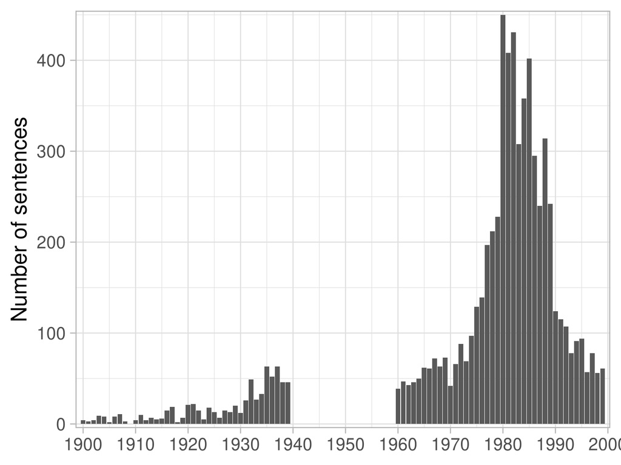

### Closest sentence from ‘rational’ and ‘rationality’ of the backbone community

| Sentence | Title | Year | Journal | Authors | Words Similarity |
| --- | --- | --- | --- | --- | --- |
| “The Monetary Mechanisms in the Light of Rational Expectations,” Rational Expectations and Economic Policy. | [The Demand and Supply of Labor and Interstate Relative Wages: An Empirical Analysis](http://www.jstor.org/stable/144135) | 1981 | Economic Geography | Gordon L. Clark , Kenneth P. Ballard | 0.819 |
| “Rational Expectations, Business Cycles, and Government Behavior,” Rational Expectations and Economic Policy. | [The Demand and Supply of Labor and Interstate Relative Wages: An Empirical Analysis](http://www.jstor.org/stable/144135) | 1981 | Economic Geography | Gordon L. Clark , Kenneth P. Ballard | 0.804 |
| I accept the basic proposition of the rational expectations theory that agents in the market must not be assumed simply to extrapolate mechanically the current rate of inflation or the recent accelera… | [Gottfried Haberler on Inflation, Unemployment, and International Monetary Economics: An Appreciation](http://www.jstor.org/stable/1882633) | 1982 | The Quarterly Journal of Economics | Thomas D. Willett | 0.801 |
| Rational Expectations and Macroeconomics Analysis Macroeconomics has been transformed in the last dozen years by the rational -expectations hypothesis and its associated econometric practices. | [Conceptual Evolution in Economics: The Case of Rational Expectations](http://www.jstor.org/stable/40324998) | 1985 | Eastern Economic Journal | Randall Bausor | 0.799 |
| Earlier versions of the paper were presented at an IMSSS workshop at Stanford on rational expectations and to monetary workshops at the University of Rochester and the University of Virginia. | [Monetary Policy and the Information Content of Prices](http://www.jstor.org/stable/1830292) | 1982 | Journal of Political Economy | Robert G. King | 0.798 |
| “Rational Expectations and the Role of Monetary Policy.” | [Informational Efficiency and the Open Economy](http://www.jstor.org/stable/1991655) | 1982 | Journal of Money, Credit and Banking | Jagdeep S. Bhandari | 0.791 |
| “Rational Expectations and the Role of Monetary Policy.” | [Relative Price Dispersion and Economic Shocks: An Inventory-Adjustment Approach](http://www.jstor.org/stable/1991707) | 1982 | Journal of Money, Credit and Banking | Yakov Amihud , Haim Mendelson | 0.791 |
| “Rational Expectations and the Role of Monetary Policy.” | [The “Rationality” of Money Supply Expectations and the Short-Run Response of Interest Rates to Monetary Surprises](http://www.jstor.org/stable/1991932) | 1981 | Journal of Money, Credit and Banking | Jacob Grossman | 0.791 |
| “Rational Expectations and the Role of Monetary Policy.” | [Monetary Accommodation of Supply Shocks under Rational Expectations](http://www.jstor.org/stable/1991933) | 1981 | Journal of Money, Credit and Banking | Alan S. Blinder | 0.791 |
| In this paper, however, I will only touch on this technical research, and instead attempt to apply some of the more general principles of rational expectations to the problem of establishing credibili… | [Establishing Credibility: A Rational Expectations Viewpoint](http://www.jstor.org/stable/1802308) | 1982 | The American Economic Review | John B. Taylor | 0.791 |
| “Rational Expectations and the Role of Monetary Policy.” | [The Influence of Unanticipated Money Growth on Real Output: Some Cross-Country Estimates](http://www.jstor.org/stable/1992160) | 1983 | Journal of Money, Credit and Banking | Clifford L. F. Attfield, Nigel W. Duck | 0.790 |
| “Rational Expectations and the Role of Monetary Policy.” | [Economic Stabilization as a Public Good: What Does It Mean?](http://www.jstor.org/stable/4537814) | 1983 | Journal of Post Keynesian Economics | Myles S. Wallace | 0.790 |
| “Rational Expectations and the Role of Monetary Policy.” | [The Derivation and Interpretation of the Lucas Supply Function](http://www.jstor.org/stable/1992142) | 1983 | Journal of Money, Credit and Banking | Clive Bull , Roman Frydman | 0.790 |
| “Rational Expectations and the Role of Monetary Policy.” | [On the Anatomy of Inflation: The Variability of Relative Commodity Prices in Argentina](http://www.jstor.org/stable/1992162) | 1983 | Journal of Money, Credit and Banking | Mario I. Blejer | 0.790 |
| “Rational Expectations and the Role of Monetary Policy.” | [Anticipated Inflation, the Frequency of Transactions, and the Slope of the Phillips Curve](http://www.jstor.org/stable/1992396) | 1983 | Journal of Money, Credit and Banking | Zvi Hercowitz | 0.790 |
| “Rational Expectations and the Role of Monetary Policy.” | [Price Controls and the Variability of Relative Prices](http://www.jstor.org/stable/1992216) | 1984 | Journal of Money, Credit and Banking | Alex Cukierman , Leonardo Leiderman | 0.789 |
| “Rational Expectations and the Role of Monetary Policy.” | [The Derivation and Interpretation of the Lucas Supply Function: Reply](http://www.jstor.org/stable/1992228) | 1984 | Journal of Money, Credit and Banking | Clive Bull , Roman Frydman | 0.789 |
| “Rational Expectations and the Role of Monetary Policy.” | [Cross-Regime Evidence of Macroeconomic Rationality](http://www.jstor.org/stable/1831087) | 1984 | Journal of Political Economy | Roger C. Kormendi, Philip G. Meguire | 0.789 |
| “Rational Expectations and the Role of Monetary Policy.” | [Fluctuating Exchange Rates and the International Transmission of Economic Disturbances](http://www.jstor.org/stable/1991883) | 1980 | Journal of Money, Credit and Banking | Nasser H. Saidi | 0.788 |
| “Rational Expectations and the Role of Monetary Policy.” | [Methods and Problems in Business Cycle Theory](http://www.jstor.org/stable/1992030) | 1980 | Journal of Money, Credit and Banking | Robert E. Lucas, Jr. | 0.788 |
| “Rational Expectations and the Role of Monetary Policy.” | [Rational Expectations and Macroeconomic Stabilization Policy: An Overview](http://www.jstor.org/stable/1992031) | 1980 | Journal of Money, Credit and Banking | Bennett T. McCallum | 0.788 |
| “Rational Expectations and the Role of Monetary Policy.” | [Market Fundamentals versus Price-Level Bubbles: The First Tests](http://www.jstor.org/stable/1837311) | 1980 | Journal of Political Economy | Robert P. Flood, Peter M. Garber | 0.788 |

### Closest sentences of the backbone community’s centroid

| Sentence | Title | Year | Journal | Authors | Centroid Similarity |
| --- | --- | --- | --- | --- | --- |
| The stream of writing which issued thereafter comprised articles and pamphlets on monetary questions and on the broader social questions of his day, and two editions of his book, Principles of Politic… | [A Neglected English Economist: George Poulett Scrope](http://www.jstor.org/stable/1885442) | 1929 | The Quarterly Journal of Economics | Redvers Opie | 0.8092383 |
| The purpose of this essay is to examine one version of this view in order to show that it does not succeed and that economists were right to treat money as worthy of special analysis. | [Money, Prices and Finance in the New Monetary Economics](http://www.jstor.org/stable/2663258) | 1988 | Oxford Economic Papers | Kevin D. Hoover | 0.7965686 |
| It will have served its purpose if it calls to the attention of students who may be discouraged by the difficulties and disagreements of equilibrium theory, by the apparent emptiness of its acknowledg… | [Equilibrium and Wealth: A Word of Encouragement to Economists](http://www.jstor.org/stable/137181) | 1939 | The Canadian Journal of Economics and Political Science / Revue canadienne d’Economique et de Science politique | K. E. Boulding | 0.7959128 |
| If we compare the chapters upon money in any systematic treatise published since the controversy with those on the same subject contained in such a book as J. S. Mill’s Principles of MARCH Political E… | [The Study of Economic History](http://www.jstor.org/stable/2221137) | 1906 | The Economic Journal | L. L. Price | 0.7850181 |
| This paper tries to clarify some of the major reasons why money did not appear to be of relevance. | [The Causal Role of Money in West Germany - Some Contradicting Comments and Evidence](http://www.jstor.org/stable/40439252) | 1984 | Weltwirtschaftliches Archiv | Jürgen von Hagen | 0.7815103 |
| It is curious that the author of this passage and the distinguished eontribution to the applied theory of money in which it occurs, should have recently been singled out for public censure for ” unsci… | [Live and Dead Issues in the Methodology of Economics](http://www.jstor.org/stable/2548633) | 1938 | Economica | Lionel Robbins | 0.7698583 |
| In it are included not only the “Common Sense” but, in addition, all of Wicksteed’s economic writings of importance except the Co-ordination of the Laws of Distribution, which has also been reprinted,… | [“The Common Sense of Political Economy” (Wicksteed Reprinted)](http://www.jstor.org/stable/1824459) | 1934 | Journal of Political Economy | Frank H. Knight | 0.7680317 |
| K Royal Economic Society GENERAL THEORY: REPLY I 145 comments on the successive drafts of the book.3 There is little if any evidence that the Treatise on Money was effectively subjected to such pre-pu… | [Mr Meade’s Relation, Kahn’s Multiplier and the Chronology of the General Theory: Reply](http://www.jstor.org/stable/2235070) | 1994 | The Economic Journal | Don Patinkin | 0.7664088 |
| The desire to treat monetary problems and indeed, more generally, problems of investment with the tools of a properly generalized Economic Theory is not merely one of aesthetics or disciplinarianism-a… | [Money and the Theory of Assets](http://www.jstor.org/stable/1905409) | 1938 | Econometrica | J. Marschak | 0.7654771 |
| The implication of this point for the controversy over the importance of money in controlling the economy is developed in the next section. | [Federal Reserve “Defensive” Behavior and the Reverse Causation Argument](http://www.jstor.org/stable/1056292) | 1973 | Southern Economic Journal | Raymond E. Lombra, Raymond G. Torto | 0.7647553 |
| This is the theory that has captured the attention, support, and imagination of a significant portion of the economics profession, but it is also the theory that has the least relevance for explaining… | [Macroeconomic Theory and Policy in an Institutionalist Perspective](http://www.jstor.org/stable/4225940) | 1987 | Journal of Economic Issues | Wallace C. Peterson | 0.7646633 |
| His early commentary on D. H. Robertson made use of the likelihood of ‘money illusion’ - that a reduction of the real wage brought about by a rise in the cost of living over against an unchanged money… | [Sir Roy Harrod: A Biographical Memoir](http://www.jstor.org/stable/2231653) | 1980 | The Economic Journal | Henry Phelps Brown | 0.7611061 |
| It will at once be recognized-except, of course, for the vital emphasis upon the importance of the concept of income-as a lineal descendent of the contention, which is at least as old as Montanari and… | [The Relation between the Velocity of Circulation of Money and the “Velocity of Circulation of Goods:” II](http://www.jstor.org/stable/1822850) | 1932 | Journal of Political Economy | Arthur W. Marget | 0.7599810 |
| Its goal is more modest: namely, to sketch the nature of the economic understanding revealed by his own published work, particularly in monetary economics, in the hope not only of providing future his… | [Karl Brunner’s Monetary Economics–An Appreciation](http://www.jstor.org/stable/1992701) | 1991 | Journal of Money, Credit and Banking | David E. W. Laidler | 0.7571139 |
| That the classical economists had a clear and insightful understanding of the effects of changes in the quantity of money has long been understood * Professor Richard M. Ebeling is Ludwig von Mises Pr… | [Knut Wicksell and the Classical Economists on Money, Credit, Interest and Price Level: A Comment on Ahiakpor](http://www.jstor.org/stable/3487775) | 1999 | The American Journal of Economics and Sociology | Richard M. Ebeling | 0.7565648 |